# Best States for American Black, Hispanic, Asian, and Female Tech – Version 1.0f

Roy L Beasley, PhD – DLL Editor

## Overview

*Please note that all of the numbers in this overview and in the subsequent report are estimates based on U.S. Census survey samples. So all numbers should be read as “approximately” even when the word “approximately” does not appear.*

- In 2015 there were approximately 148,297,138 workers in the entire U.S. workforce. Approximately 135,475,088 were American citizens; 12,822,050 were foreign workers who moved here to work for their employers. (See Table 1A)
- In 2015, there were approximately 4,636,487 workers in the information technology sectors of the 50 states and the District of Columbia; 4,066,773 were Americans; 569,714 were foreign tech professionals *.See Chart 1, below*

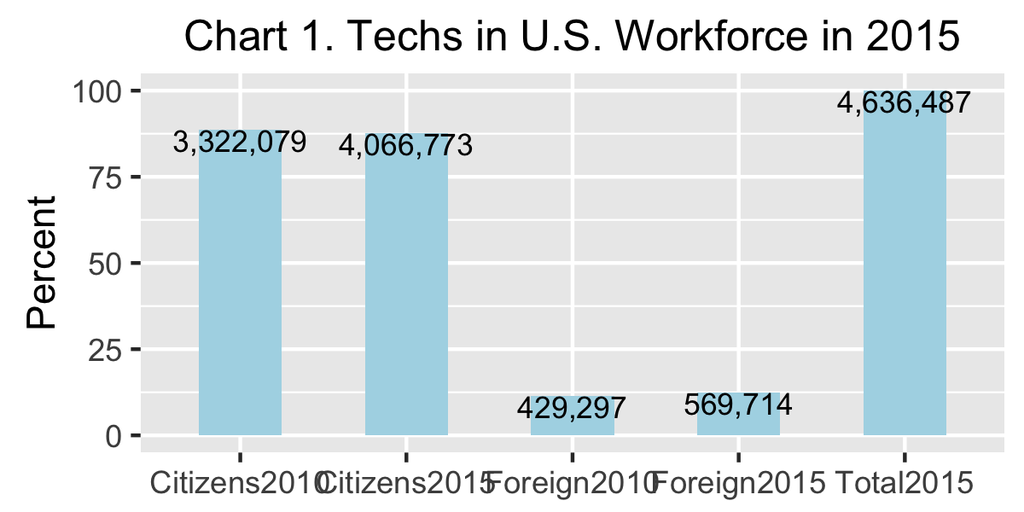

- In 2015 there were approximately 2,916,852 White Americans in U.S. tech; 314,497 Black Americans; 282,946 Hispanic Americans; 443,434 Asian Americans; and 109,044 were from other racial/ethnic groups *(See Chart 2, below.)*

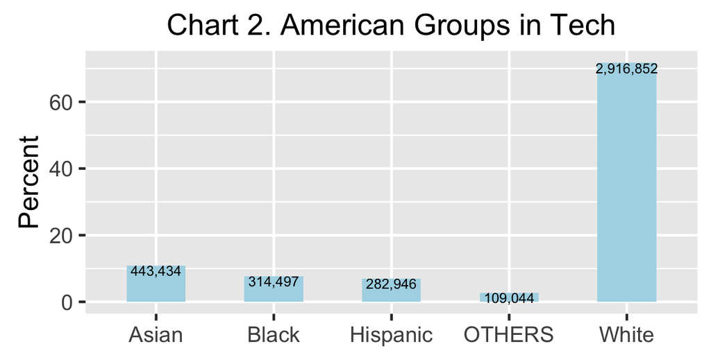

- Approximately 1,039,074 American techs were female; 3,027,699 were male. Approximately 128,871 American female techs were Asian-American; and 910,203 were non-Asian American. *(See Chart 3, below.)*

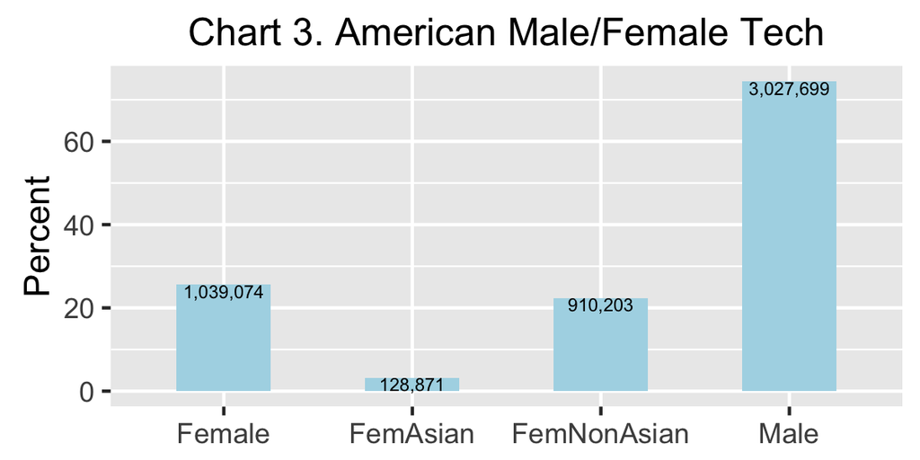

- If all other things were equal, one would expect that the percentage of a state’s tech sector that was Black American would be about the same as the percentage of the state’s total workforce that was Black American. One would expect similar parity for the percentages of Hispanic Americans and for American females.  
  But all things were not equal. The percentage of the tech sector of most states that was American Black, Hispanic, or female was substantially smaller than the percentage of the state’s total workforce that was American Black, Hispanic, or female. By contrast, the percentage of state tech sectors that was Asian American was usually greater than the Asian American percentage of the total workforce population in each state, ranging as high as 5.68 times that percentage, (See Tables 4C and 6)
- The subgroup of Asian American females occupied disproportionately larger shares of the tech sectors in most states. Indeed, their tech shares ranged as high as 7 times their shares of state workforce populations. (See Table 6.) By contrast, the subgroup of non-Asian American females occupied much smaller shares of state tech sectors than their shares of state workforce populations. (See Table 6.)
- The number of tech jobs held by Americans grew by 22.4 percent between 2010 and 2015, i.e., from 3,322,079 to 4,066,773; the number tech jobs held by White Americans grew by 16.8 percent, i.e., from 2,497,966 to 2,916,852; tech jobs held by Black Americans grew by 31.1 percent, i.e., from 239,866 to 314,497; tech jobs held by Asian Americans grew by 36.2 percent, i.e., from 325,603 to 443,434; and tech jobs held by Hispanic Americans grew by 51.9 percent, i.e., from 186,284 to 282,946. *(See Chart 4, and Table3EE.)*

[figure not shown]

- The number of tech jobs held by American females grew by 15.4 percent between 2010 and 2015, i.e., from 900,283, to 1,039,074. However American females occupied a smaller percentage of the tech jobs held by American tech professionals in 2015 than they did in 2010, i.e., 27.1 percent in 2010 compared to only 25.6 percent in 2015. (See Table 3Z and 3ZZ)
- The number of tech jobs held by foreign professionals in U.S. tech grew by 140,417 or 32.7 percent between 2010 and 2015, i.e., from 429,297 to 569,714. *(See Chart 4, above.)*
- The 407,481 professionals imported from Asia in 2015 was substantially larger than the 314,497 Black American or the 282,946 Hispanic American professionals employed by U.S. tech in 2015. Indeed, the 569,714 combined total of foreign professionals imported from Asia and from elsewhere in 2015 was almost as large as the 597,443 combined total of Black and Hispanic American professionals employed by U.S. tech. (See Tables 1D and 1E.)
- The best states for Black American tech professionals were HBCU states: Dist of Col, Georgia, Maryland, Virginia and Texas. (See Table 8B)
- The best states for Hispanic American tech professionals were Florida, Colorado, New York, and Virginia. (See Table 8D)
- The best states for Asian American tech professionals were New Jersey, Massachusetts, Illinois, Texas, and Georgia. (See Table 8C)

[back-to-top](https://archimedes2kxx.github.io/BestStatesForBlackTech/Report-3.html)

## Findings

Brief answers to the first three sets of questions provide a broad statistical framwork for the extended responses to the fourth and fifth questions that form the core of this report.

#### Question 1 – How large was the total U.S. workforce and the U.S. tech sector in 2015?

*Question 1A* – How many American workers were in the U.S. workforce in 2015? How many foreign workers? (*Note: the workforce contained persons 16 and over who held a job or were temporarily unemployed.*)

*Answer 1A* The answers to this question are shown in Table 1A (below).

*Note that many of the tables in this section have the same format. The top row, labelled “Num” as an abbreviation for “Number”, shows how many workers fall into the category of the heading of the column: American “Citizen”, “Foreign” worker, and their combined “Total”. The second row, labelled “Per” as short for “Percentage”, shows the percentge of the “Total” for each of the numbers in the first row.*

**Table 1A – American and Foreign Components of the U.S. Workforce in the 50 states plus the District of Columbia in 2015**

```
    Total       Citizens    Foreign
Num 148,297,138 135,475,088 12,822,050
Per 100         91.4        8.6
```

[back-to-top](https://archimedes2kxx.github.io/BestStatesForBlackTech/Report-3.html)

*Question 1B* – How large were the White, Black, Asian, and Hispanic American components of the U.S. workforce in the 50 states plus the District of Columbia in 2015?

*Answer 1B* … In 2015, as shown in Table 1B (below), there were approximately 135,475,088 citizens in the workforce, a/k/a “labor force”, in the 50 states plus DC. in 2015? The largest of the four racial/ethnic groups discussed in this report was White American (93,526,664); the smallest was Asian American (5,901,978). Hispanic American, the largest minority (16,710,406), was larger than Black American (15,743,152).

*Note that the last column “OTHERS” includes workers who described themselves as members of another racial broup not included in the previous categories, or as biracial or multiracial. Also note that “White”, “Black”, and “Asian” include workers who described themselves as “White, but not Hispanic”, “Black, but not Hispnic”, and “Asian, but not Hispanic”.*

**Table 1B – American Racial/Ethnic Groups in the U.S. Workforce in the 50 states plus the District of Columbia in 2015**

```
    Total       White      Black      Asian     Hispanic   OTHERS
Num 135,475,088 93,526,664 15,743,152 5,901,978 16,710,406 3,592,888
Per 100         69         11.6       4.4       12.3       2.7
```

[back-to-top](https://archimedes2kxx.github.io/BestStatesForBlackTech/Report-3.html)

*Question 1C* – How many U.S. citizens and how many foreign employees worked in the the tech sectors of the 50 states plus the District of Columbia in 2015

*Answer 1C* … Most of the tables in this report will deal with American techs or foreign techs, but not both. Therefore the counts in the second and third columns of this small table will recur in many subsequent tables.

**Table 1C – American and Foreign Components of the U.S. Tech Sector in 2015**

```
    Total2010 Citizens2010 Foreign2010 Total2015 Citizens2015 Foreign2015
Num 3,751,376 3,322,079    429,297     4,636,487 4,066,773    569,714
Per 100       88.6         11.4        100       87.7         12.3
```

[back-to-top](https://archimedes2kxx.github.io/BestStatesForBlackTech/Report-3.html)

*Question 1D* – How many White, Black, Asian, and Hispanic Americans were in the U.S. tech sector of the 50 states plus the District of Columbia in 2015?

*Answer 1D* … As shown in Table 1B (below), there were approximately 4,066,773 American tech professionals in the U.S. in 2015. White Americans were a substantial majority (2,916,852) of the tech sector (71.7%); Asians placed second (443,434); Blacks showed third (314,497); and Hispanic Americans came in fourth (282,946)

**Table 1D – American Racial/Ethnic Groups in the U.S. Tech Sector in 2015**

```
    Total     White     Black   Asian   Hispanic OTHERS
Num 4,066,773 2,916,852 314,497 443,434 282,946  109,044
Per 100       71.7      7.7     10.9    7        2.7
```

[back-to-top](https://archimedes2kxx.github.io/BestStatesForBlackTech/Report-3.html)

*Question 1E* – How many Asian and non-Asian foreign employees were in U.S. tech in the 50 states plus the District of Columbia in 2015?

*Answer 1E* … The total number of tech workers imported from Asia and from countries outside of Asia shown in Table 1E (below) will recur in subsequent tables.

**Table 1E – Foreign Asian and Non-Asian Components of the U.S. Tech Sector in 2015**

```
    Total   Asian   NonAsian
Num 569,714 407,481 162,233
Per 100     71.5    28.5
```

[back-to-top](https://archimedes2kxx.github.io/BestStatesForBlackTech/Report-3.html)

#### Question 2 – What was the American male/female composition of U.S. workforce and tech sector in 2015?

*Question 2A* – What was the American male/female composition of the U.S. workforce in the 50 states plus the District of Columbia in 2015?

*Answer 2A* … As shown in Table 2A (below), the U.S. workforce was close to an even split between males and females. But given the focus of this report, the table also breaks the female half into a small Asian component (2.2 percent) and a much larger non-Asian female component (45.8 percent)

**Table 2A – American Male/Female Composition of the U.S. Workforce in 2015**

```
    Total       Male        Female      FemAsian    FemNonAsian
Num 135,475,088 70,447,742  65,027,346  2,931,010   62,096,336
Per 100         52          48          2.2         45.8
```

*Question 2B* – What was the American male/female composition of the tech sector in the 50 states plus the District of Columbia in 2015?

Answer 2B … As shown in Table 2B (below), the ratio of American male to American female techs was about 3 to 1, more specifically 74.4 percent to 25.6 percent. The ratio of Non-Asian American females to Asian American females was about 7 to 1, i.e., 22.4 percent to 3.2 percent.

**Table 2B – American Male/fFemale Composition of the U.S. Tech Sector in 2015**

```
    Total     Male      Female    FemAsian  FemNonAsian
Num 4,066,773 3,027,699 1,039,074 128,871   910,203
Per 100       74.4      25.6      3.2       22.4
```

[back-to-top](https://archimedes2kxx.github.io/BestStatesForBlackTech/Report-3.html)

#### Question 3 – How did the racial, ethnic, foreign, and male/female shares of jobs in U.S. tech change between 2010 and 2015?

The six pairs of tables in this section display profiles of the various groups considered in this report.

For the purposes of this report, “information technology” was defined as the thirteen standard occupation categories (SOC) that appear in the first column of the following tables. Twelve related to software, e.g., Software Developers and Computer Programmers; one related to hardware, i.e., Computer Hardware Engineers.

*Question 3.0* – How many American male vs. female techs were in each category in 2010 and 2015 in the 50 states and the District of Columbia?

*Answer 3.0* … As per its title, Tables 3Z and 3ZZ (below) only contain data about tech workers who were American citizens; data about foreign workers will appear in Tables 3E and 3EE. An important statistic that can be derived from the data in Table 3ZZ is that 900,283 techs in 2010 were female, i.e., 27.1 percent of 3,322,079.

**Table 3Z – American Male/Female Composition of U.S. Tech in 2015**

```
                     Occupation perTS    Tech15       Fem perF15
                All Occupations 100.0 4,066,773 1,039,074   25.6
            SOFTWARE DEVELOPERS  22.2   903,442   183,800   20.3
   COMPUTER SUPPORT SPECIALISTS  14.6   594,490   147,645   24.8
 COMPUTER OCCUPATIONS ALL OTHER  13.1   532,369   128,808   24.2
 COMPUTER/INFO SYSTEMS MANAGERS  13.0   527,801   153,180   29.0
      COMPUTER SYSTEMS ANALYSTS  10.5   425,677   169,390   39.8
           COMPUTER PROGRAMMERS   9.5   386,212    82,890   21.5
    NETWORK/COMP SYSTEMS ADMINS   4.8   196,517    36,571   18.6
                 WEB DEVELOPERS   4.4   177,299    65,555   37.0
        DATABASE ADMINISTRATORS   2.4    99,523    36,896   37.1
    COMPUTER NETWORK ARCHITECTS   2.4    97,108     8,239    8.5
  INFORMATION SECURITY ANALYSTS   1.6    64,555    14,336   22.2
    COMPUTER HARDWARE ENGINEERS   1.1    45,238     6,811   15.1
  COMP/INFO RESEARCH SCIENTISTS   0.4    16,542     4,953   29.9
```

**Table 3ZZ – Changes in the American Composition of U.S. Tech Between 2010 and 2015**

```
                     Occupation    Tech10    Tech15  Change perCh perF10
                All Occupations 3,322,079 4,066,773 744,694  22.4   27.1
            SOFTWARE DEVELOPERS   659,612   903,442 243,830  37.0   22.0
   COMPUTER SUPPORT SPECIALISTS   483,108   594,490 111,382  23.1   28.5
 COMPUTER OCCUPATIONS ALL OTHER   284,682   532,369 247,687  87.0   23.8
 COMPUTER/INFO SYSTEMS MANAGERS   447,877   527,801  79,924  17.8   32.3
      COMPUTER SYSTEMS ANALYSTS   400,925   425,677  24,752   6.2   37.2
           COMPUTER PROGRAMMERS   402,970   386,212 -16,758  -4.2   23.2
    NETWORK/COMP SYSTEMS ADMINS   209,298   196,517 -12,781  -6.1   18.9
                 WEB DEVELOPERS   144,466   177,299  32,833  22.7   36.0
        DATABASE ADMINISTRATORS    95,143    99,523   4,380   4.6   39.8
    COMPUTER NETWORK ARCHITECTS    84,261    97,108  12,847  15.2    8.9
  INFORMATION SECURITY ANALYSTS    45,484    64,555  19,071  41.9   25.9
    COMPUTER HARDWARE ENGINEERS    49,655    45,238  -4,417  -8.9   14.2
  COMP/INFO RESEARCH SCIENTISTS    14,598    16,542   1,944  13.3   39.8
```

[back-to-top](https://archimedes2kxx.github.io/BestStatesForBlackTech/Report-3.html)

*Question 3A* – How many White American male vs. female techs were in each category in 2010 and 2015 in the 50 states and the District of Columbia?

*Answer 3A* … Data for White American techs in 2015 is in Table 3A; data that compares 2010 to 2015 is in Table 3AA.

**Table 3A – White American Male/Female Composition of U.S. Tech in 2015**

```
                     Occupation perTS    Tech15     Fem perF15
                All Occupations 100.0 2,916,852 697,326   23.9
            SOFTWARE DEVELOPERS  21.9   638,256 108,552   17.0
   COMPUTER SUPPORT SPECIALISTS  14.1   412,295  94,199   22.8
 COMPUTER/INFO SYSTEMS MANAGERS  13.7   400,345 114,607   28.6
 COMPUTER OCCUPATIONS ALL OTHER  12.6   368,422  86,457   23.5
      COMPUTER SYSTEMS ANALYSTS  10.2   296,373 115,212   38.9
           COMPUTER PROGRAMMERS   9.9   289,070  54,997   19.0
    NETWORK/COMP SYSTEMS ADMINS   5.0   145,558  27,213   18.7
                 WEB DEVELOPERS   4.7   137,938  49,587   35.9
    COMPUTER NETWORK ARCHITECTS   2.4    71,035   5,212    7.3
        DATABASE ADMINISTRATORS   2.4    69,084  25,525   36.9
  INFORMATION SECURITY ANALYSTS   1.6    46,732   9,159   19.6
    COMPUTER HARDWARE ENGINEERS   1.1    31,049   3,242   10.4
  COMP/INFO RESEARCH SCIENTISTS   0.4    10,695   3,364   31.5
```

**Table 3AA – Changes in the White American Composition of U.S. Tech Between 2010 and 2015**

```
                     Occupation    Tech10    Tech15  Change perCh perF10
                All Occupations 2,497,966 2,916,852 418,886  16.8   25.8
            SOFTWARE DEVELOPERS   483,755   638,256 154,501  31.9   19.3
   COMPUTER SUPPORT SPECIALISTS   349,548   412,295  62,747  18.0   27.7
 COMPUTER/INFO SYSTEMS MANAGERS   357,530   400,345  42,815  12.0   31.0
 COMPUTER OCCUPATIONS ALL OTHER   203,674   368,422 164,748  80.9   23.2
      COMPUTER SYSTEMS ANALYSTS   294,095   296,373   2,278   0.8   36.4
           COMPUTER PROGRAMMERS   316,013   289,070 -26,943  -8.5   21.0
    NETWORK/COMP SYSTEMS ADMINS   160,183   145,558 -14,625  -9.1   18.5
                 WEB DEVELOPERS   117,545   137,938  20,393  17.3   36.7
    COMPUTER NETWORK ARCHITECTS    63,625    71,035   7,410  11.6    7.2
        DATABASE ADMINISTRATORS    72,566    69,084  -3,482  -4.8   39.9
  INFORMATION SECURITY ANALYSTS    34,741    46,732  11,991  34.5   24.5
    COMPUTER HARDWARE ENGINEERS    34,151    31,049  -3,102  -9.1   10.7
  COMP/INFO RESEARCH SCIENTISTS    10,540    10,695     155   1.5   38.9
```

[back-to-top](https://archimedes2kxx.github.io/BestStatesForBlackTech/Report-3.html)

*Question 3B* – How many Black American male vs. female techs were in each category in 2010 and 2015 in the 50 states and the District of Columbia?

*Answer 3B* … Data for Black American techs in 2015 is in Table 3B; data that compares 2010 to 2015 is in Table 3BB.

**Table 3B – Black American Male/Female Composition of U.S. Tech in 2015**

```
                     Occupation perTS  Tech15     Fem perF15
                All Occupations 100.0 314,497 113,533   36.1
   COMPUTER SUPPORT SPECIALISTS  21.1  66,489  25,584   38.5
 COMPUTER OCCUPATIONS ALL OTHER  18.1  56,883  16,811   29.6
            SOFTWARE DEVELOPERS  14.0  44,130  13,931   31.6
      COMPUTER SYSTEMS ANALYSTS  12.6  39,552  20,888   52.8
 COMPUTER/INFO SYSTEMS MANAGERS  11.0  34,750  13,288   38.2
           COMPUTER PROGRAMMERS   7.4  23,257   9,024   38.8
    NETWORK/COMP SYSTEMS ADMINS   4.4  13,746   2,937   21.4
        DATABASE ADMINISTRATORS   2.8   8,882   3,263   36.7
                 WEB DEVELOPERS   2.7   8,362   3,260   39.0
  INFORMATION SECURITY ANALYSTS   2.4   7,659   2,854   37.3
    COMPUTER NETWORK ARCHITECTS   2.3   7,323     700    9.6
    COMPUTER HARDWARE ENGINEERS   0.7   2,052     439   21.4
  COMP/INFO RESEARCH SCIENTISTS   0.4   1,412     554   39.2
```

**Table 3BB – Changes in the Black American Composition of U.S. Tech Between 2010 and 2015**

```
                     Occupation  Tech10  Tech15 Change perCh perF10
                All Occupations 239,866 314,497 74,631  31.1   38.8
   COMPUTER SUPPORT SPECIALISTS  53,757  66,489 12,732  23.7   38.1
 COMPUTER OCCUPATIONS ALL OTHER  29,093  56,883 27,790  95.5   31.0
            SOFTWARE DEVELOPERS  32,849  44,130 11,281  34.3   41.8
      COMPUTER SYSTEMS ANALYSTS  37,485  39,552  2,067   5.5   43.0
 COMPUTER/INFO SYSTEMS MANAGERS  27,189  34,750  7,561  27.8   52.2
           COMPUTER PROGRAMMERS  16,775  23,257  6,482  38.6   33.8
    NETWORK/COMP SYSTEMS ADMINS  16,507  13,746 -2,761 -16.7   28.7
        DATABASE ADMINISTRATORS   7,434   8,882  1,448  19.5   47.6
                 WEB DEVELOPERS   4,903   8,362  3,459  70.5   26.3
  INFORMATION SECURITY ANALYSTS   4,132   7,659  3,527  85.4   38.9
    COMPUTER NETWORK ARCHITECTS   5,853   7,323  1,470  25.1   21.9
    COMPUTER HARDWARE ENGINEERS   2,333   2,052   -281 -12.0   31.4
  COMP/INFO RESEARCH SCIENTISTS   1,556   1,412   -144  -9.3   48.1
```

[back-to-top](https://archimedes2kxx.github.io/BestStatesForBlackTech/Report-3.html)

**Table 3C – Asian American Male/Female Composition of U.S. Tech in 2015**

```
                     Occupation perTS  Tech15     Fem perF15
                All Occupations 100.0 443,434 128,871   29.1
            SOFTWARE DEVELOPERS  33.6 148,909  46,058   30.9
      COMPUTER SYSTEMS ANALYSTS  11.4  50,518  17,855   35.3
 COMPUTER OCCUPATIONS ALL OTHER  11.0  48,793  12,439   25.5
 COMPUTER/INFO SYSTEMS MANAGERS  10.7  47,565  12,349   26.0
           COMPUTER PROGRAMMERS   9.8  43,677  13,686   31.3
   COMPUTER SUPPORT SPECIALISTS   9.5  42,308   8,547   20.2
    NETWORK/COMP SYSTEMS ADMINS   3.0  13,189   2,602   19.7
                 WEB DEVELOPERS   2.9  12,714   6,223   48.9
        DATABASE ADMINISTRATORS   2.7  11,832   4,536   38.3
    COMPUTER HARDWARE ENGINEERS   1.9   8,456   2,167   25.6
    COMPUTER NETWORK ARCHITECTS   1.9   8,350     934   11.2
  INFORMATION SECURITY ANALYSTS   0.9   4,163     756   18.2
  COMP/INFO RESEARCH SCIENTISTS   0.7   2,960     719   24.3
```

**Table 3CC – Changes in the Asian American Composition of U.S. Tech Between 2010 and 2015**

```
                     Occupation  Tech10  Tech15  Change perCh perF10
                All Occupations 325,603 443,434 117,831  36.2   29.4
            SOFTWARE DEVELOPERS 100,055 148,909  48,854  48.8   28.6
      COMPUTER SYSTEMS ANALYSTS  39,474  50,518  11,044  28.0   36.3
 COMPUTER OCCUPATIONS ALL OTHER  24,148  48,793  24,645 102.1   23.3
 COMPUTER/INFO SYSTEMS MANAGERS  34,342  47,565  13,223  38.5   30.2
           COMPUTER PROGRAMMERS  44,323  43,677    -646  -1.5   34.5
   COMPUTER SUPPORT SPECIALISTS  29,603  42,308  12,705  42.9   24.4
    NETWORK/COMP SYSTEMS ADMINS  14,141  13,189    -952  -6.7   18.0
                 WEB DEVELOPERS   9,377  12,714   3,337  35.6   36.7
        DATABASE ADMINISTRATORS   9,649  11,832   2,183  22.6   40.3
    COMPUTER HARDWARE ENGINEERS   8,507   8,456     -51  -0.6   23.4
    COMPUTER NETWORK ARCHITECTS   7,361   8,350     989  13.4   12.4
  INFORMATION SECURITY ANALYSTS   2,780   4,163   1,383  49.7   28.6
  COMP/INFO RESEARCH SCIENTISTS   1,843   2,960   1,117  60.6   31.7
```

[back-to-top](https://archimedes2kxx.github.io/BestStatesForBlackTech/Report-3.html)

*Question 3D* – How many Hispanic American male vs. female techs were in each category in 2010 and 2015 in the 50 states and the District of Columbia?

*Answer 3D* … Data for Hispanic American techs in 2015 is in Table 3D; data that compares 2010 to 2015 is in Table 3DD.

**Table 3D – Hispanic American Male/Female Composition of U.S. Tech in 2015**

```
                     Occupation perTS  Tech15    Fem perF15
                All Occupations 100.0 282,946 72,541   25.6
   COMPUTER SUPPORT SPECIALISTS  20.5  58,123 15,414   26.5
            SOFTWARE DEVELOPERS  16.8  47,637  9,552   20.1
 COMPUTER OCCUPATIONS ALL OTHER  15.3  43,349  9,937   22.9
 COMPUTER/INFO SYSTEMS MANAGERS  11.3  31,892  8,739   27.4
      COMPUTER SYSTEMS ANALYSTS  10.5  29,689 12,792   43.1
           COMPUTER PROGRAMMERS   7.2  20,383  4,095   20.1
    NETWORK/COMP SYSTEMS ADMINS   6.8  19,179  2,830   14.8
                 WEB DEVELOPERS   4.4  12,523  3,782   30.2
    COMPUTER NETWORK ARCHITECTS   2.5   7,044  1,160   16.5
        DATABASE ADMINISTRATORS   2.2   6,260  2,512   40.1
  INFORMATION SECURITY ANALYSTS   1.1   3,231    529   16.4
    COMPUTER HARDWARE ENGINEERS   1.0   2,819    963   34.2
  COMP/INFO RESEARCH SCIENTISTS   0.3     817    236   28.9
```

**Table 3DD – Changes in the Hispanic American Composition of U.S. Tech Between 2010 and 2015**

```
                     Occupation  Tech10  Tech15 Change perCh perF10
                All Occupations 186,284 282,946 96,662  51.9   24.1
   COMPUTER SUPPORT SPECIALISTS  36,076  58,123 22,047  61.1   24.9
            SOFTWARE DEVELOPERS  29,639  47,637 17,998  60.7   21.9
 COMPUTER OCCUPATIONS ALL OTHER  21,713  43,349 21,636  99.6   19.2
 COMPUTER/INFO SYSTEMS MANAGERS  20,919  31,892 10,973  52.5   31.1
      COMPUTER SYSTEMS ANALYSTS  22,085  29,689  7,604  34.4   36.9
           COMPUTER PROGRAMMERS  18,660  20,383  1,723   9.2   20.4
    NETWORK/COMP SYSTEMS ADMINS  13,964  19,179  5,215  37.3   13.9
                 WEB DEVELOPERS   7,422  12,523  5,101  68.7   25.3
    COMPUTER NETWORK ARCHITECTS   4,933   7,044  2,111  42.8   10.5
        DATABASE ADMINISTRATORS   4,610   6,260  1,650  35.8   22.4
  INFORMATION SECURITY ANALYSTS   2,537   3,231    694  27.4   25.4
    COMPUTER HARDWARE ENGINEERS   3,134   2,819   -315 -10.1   12.3
  COMP/INFO RESEARCH SCIENTISTS     592     817    225  38.0   60.8
```

[back-to-top](https://archimedes2kxx.github.io/BestStatesForBlackTech/Report-3.html)

*Question 3E* – How many foreign male vs. female techs were in each category in 2010 and 2015 in the 50 states and the District of Columbia?

*Answer 3E* … Data for foreign techs in 2015 is in Table 3E; data that compares 2010 to 2015 is in Table 3EE.

**Table 3E – Foreign Male/Female Composition of U.S. Tech in 2015**

```
                     Occupation perTS  Tech15     Fem perF15
                All Occupations 100.0 569,714 113,831   20.0
            SOFTWARE DEVELOPERS  46.8 266,807  51,931   19.5
      COMPUTER SYSTEMS ANALYSTS   9.4  53,269  13,328   25.0
           COMPUTER PROGRAMMERS   9.1  52,082  10,223   19.6
 COMPUTER/INFO SYSTEMS MANAGERS   8.7  49,546   6,900   13.9
 COMPUTER OCCUPATIONS ALL OTHER   7.9  45,020   9,618   21.4
   COMPUTER SUPPORT SPECIALISTS   7.6  43,017   8,756   20.4
        DATABASE ADMINISTRATORS   2.5  14,069   3,351   23.8
                 WEB DEVELOPERS   2.0  11,193   4,045   36.1
    NETWORK/COMP SYSTEMS ADMINS   2.0  11,149   1,828   16.4
    COMPUTER NETWORK ARCHITECTS   1.9  10,909   1,258   11.5
    COMPUTER HARDWARE ENGINEERS   1.2   6,979   1,677   24.0
  COMP/INFO RESEARCH SCIENTISTS   0.7   3,752     387   10.3
  INFORMATION SECURITY ANALYSTS   0.3   1,922     529   27.5
```

**Table 3EE – Changes in the Foreign Composition of U.S. Tech Between 2010 and 2015**

```
                     Occupation  Tech10  Tech15  Change perCh perF10
                All Occupations 429,297 569,714 140,417  32.7   21.6
            SOFTWARE DEVELOPERS 187,359 266,807  79,448  42.4   21.1
      COMPUTER SYSTEMS ANALYSTS  57,571  53,269  -4,302  -7.5   25.1
           COMPUTER PROGRAMMERS  52,377  52,082    -295  -0.6   22.5
 COMPUTER/INFO SYSTEMS MANAGERS  35,164  49,546  14,382  40.9   16.7
 COMPUTER OCCUPATIONS ALL OTHER  19,406  45,020  25,614 132.0   20.6
   COMPUTER SUPPORT SPECIALISTS  25,045  43,017  17,972  71.8   23.6
        DATABASE ADMINISTRATORS   9,250  14,069   4,819  52.1   32.0
                 WEB DEVELOPERS   8,895  11,193   2,298  25.8   27.1
    NETWORK/COMP SYSTEMS ADMINS  13,719  11,149  -2,570 -18.7   13.7
    COMPUTER NETWORK ARCHITECTS   8,335  10,909   2,574  30.9   10.7
    COMPUTER HARDWARE ENGINEERS   8,549   6,979  -1,570 -18.4   24.5
  COMP/INFO RESEARCH SCIENTISTS   2,183   3,752   1,569  71.9   26.5
  INFORMATION SECURITY ANALYSTS   1,444   1,922     478  33.1   20.3
```

[back-to-top](https://archimedes2kxx.github.io/BestStatesForBlackTech/Report-3.html)

#### Question 4 – Where did American tech professionals work in 2015?

Answer 4 … The following sections provide an extensive response to a more specific formulation of this question ==> In which states did American tech professionals work in 2015?

Table 4 (below) lists the six states that employed the most American techs in 2015. These states will also appear in just about every table that follows because they employed such a large share (40.2 percent) of the 4,066,773 American techs in the U.S.

**Table 4 … Biggest Half-Dozen Tech States in 2015**

```
 ALL STATES      CA      TX      NY      FL      VA      IL perT6
  4,066,773 513,031 328,635 240,885 193,697 186,597 173,972  40.2
```

I’ve presented U.S. Census data that shows the geographic distribution of tech professionals in two formats: (1) as a set of choropleth maps and (2) as a corresponding set of tables. I have shown the maps first because it’s easier to see the workplace patterns of the racial/ethnic/female groups by looking at multicolored maps than by scanning columns of data in long tables. Indeed, a quick scan of the maps makes it easier to spot the same patterns in the data tables.

**Maps 4A (Whites), 4B (Blacks), 4C (Asians), 4D (Hispanics), 4E (Asian Females), and 4F (Non-Asian Females)** … *Lower 48 and DC*

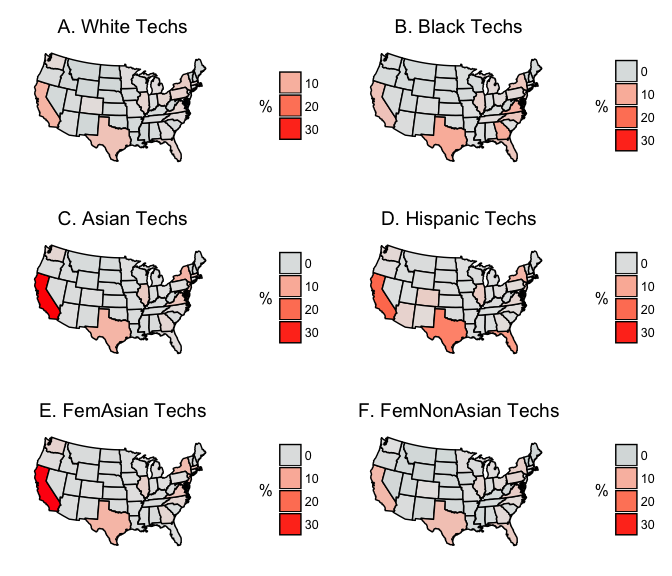

[back-to-top](https://archimedes2kxx.github.io/BestStatesForBlackTech/Report-3.html)

**Tables 4A, 4B, 4C, 4D, 4E, 4F** … *50 states plus DC*  
Six data tables impose numeric precision on the qualitative insights provided by the corresponding maps. The tables are ordered by the number of techs from each group that worked in each state. The short versions that only contain the top ten rows are displayed below. To view the full tables that contain data for all 50 states plus the District of Columbia, please click the link below the table name. Each table (full and short versions) has the following eight columns:  
1. **State** – State of workplace for the American techs whose data is shown in the other columns of each row  
2. **AllTech** – Data for all of American techs in the U.S. The data in this column is repeated in each of the six tables, but the order of the rows differs from one table to the next. For example Table 4A shows that the total number of techs in California in 2015 was 513,031, and the total number in Texas was 328,635  
3. **perSS** – The state’s share of each group’s national total. More specifically, the percent of all American techs in a group that worked in each state. For example, Table 4A shows that 9.3 percent of all White techs worked in California in 2015, and 7 percent worked in Texas.  
4. **WhiTech, BlkTech, AsiTech, HispTech, FemAsiTech, or FemNonAsTech** – White techs, Black techs, Asian techs, Hispanic techs, Asian female techs, and Non-Asian female techs in tables A, B, C, D, E, and F, respectively. The data in this column shows the number of techs from the table’s group that worked in each state. For example, Table 4A shows that 270,034 White techs worked in California, and 205,636 White techs worked in Texas. **The rows of each table are ordered by data in this column, i.e., by the number of techs in each state; states with higher numbers are at the top of the table; states with lower numbers are at the bottom.**  
5. **perT** – Percent of a state’s techs who were in the table’s group. For exampleTable 4A shows that 52.6 percent of the techs in California were White, and 62.6 percent of the techs in Texas were White.  
6. **WhiPop, BlkPop, AsiPop, HspPop, FemAsiPop, or FemNonAsiPop** – White, Black, Asian, Hispanic, female Asian, or female non-Asian components of the workforce in each state. For example, Table 4A shows that the White component of the California workforce in 2015 was 6,833,959, and the White component of the Texas workforce was 5,642,859.  
7. **perP** – Percent of the state’s total workforce that belonged to the table’s group. For example, Table 4A shows that in 2015, 46.5 percent of the total workforce of California was White, and 52 percent of the total workforce of Texas was white  
.  
8. **Par** – Parity = The ratio of the percent of the state’s tech workforce that belonged to the table’s group divided by the percent of the state’s total workforce that belonged to that group, i.e., perT / perP. For example, Table 4A shows that the White parity ratio for California was 1.13, which is 52.6% divided by 46.5%

**Table 4A – White American Professionals in U.S. Information Technology – Top 10 States**  
*Click here for full version*

```
         State   AllTech perSS   WhiTech perT     WhiPop perP  Par
    ALL STATES 4,066,773 100.0 2,916,852 71.7 93,526,664 69.0 1.04
    California   513,031   9.3   270,034 52.6  6,833,959 46.5 1.13
         Texas   328,635   7.0   205,636 62.6  5,642,859 52.0 1.20
      New York   240,885   5.5   159,512 66.2  5,471,519 64.5 1.03
  Pennsylvania   154,066   4.5   130,915 85.0  4,730,650 83.3 1.02
       Florida   193,697   4.5   130,007 67.1  4,673,939 59.9 1.12
      Illinois   173,972   4.3   126,806 72.9  3,906,703 71.1 1.03
      Virginia   186,597   4.2   121,439 65.1  2,499,305 67.3 0.97
          Ohio   135,563   4.0   116,168 85.7  4,452,326 84.5 1.01
 Massachusetts   136,709   3.7   108,301 79.2  2,585,847 80.4 0.99
    Washington   132,266   3.6   104,723 79.2  2,333,814 76.8 1.03
```

**Comments about Table 4A – White American Professionals in Tech**

- The numbers in the third (perSS) and fourth (WhiTech) columns of this table, i.e., the percentage of the nation’s White techs who worked in each state and the estimated number of techs (WhiTech) in each state are equivalent to the colors on Map 4A. Indeed, the colors on this map are based on the numbers in these columns.
- To be specific, the third and fourth columns show that in 2015 the largest number of White techs worked in California; the next largest worked in Texas. White techs were found in every state after that in smaller and smaller numbers.
- This story is captured by the parity values in the last column (Par) of Table 4A (and in its full version). White parity values were all close to 1.0. Therefore the percentage of techs who were White in each state was more or less the same as the percentage of Whites in the state’s total workforce. In other words, if you walked into a tech office in any state in the USA, you would probably encounter the same percentage of White techs as the percentage of White people you would encounter walking down the street in that state – with an important caveat: random encounters with 10 White people on a street would only involve five males; but as per Table 3 (above), random encounters with 10 White techs in an office would probably involve seven or eight males.

  [back-to-top](https://archimedes2kxx.github.io/BestStatesForBlackTech/Report-3.html)

**Table 4B – Black American Professionals in U.S. Information Technology – Top 10 states**  
*Click here for full version*

```
          State   AllTech perSS BlkTech perT     BlkPop perP  Par
     ALL STATES 4,066,773 100.0 314,497  7.7 15,743,152 11.6 0.66
          Texas   328,635  10.0  31,437  9.6  1,396,038 12.9 0.74
        Georgia   129,978   9.9  31,211 24.0  1,286,685 30.6 0.78
       Virginia   186,597   9.0  28,381 15.2    728,267 19.6 0.78
       Maryland   119,152   7.3  23,000 19.3    632,387 25.1 0.77
     California   513,031   6.1  19,068  3.7    876,211  6.0 0.62
       New York   240,885   5.4  17,100  7.1  1,110,478 13.1 0.54
        Florida   193,697   5.4  16,999  8.8  1,162,812 14.9 0.59
 North Carolina   127,484   5.4  16,986 13.3    888,815 21.0 0.63
    Dist of Col    50,301   5.3  16,558 32.9    256,515 34.4 0.96
       Illinois   173,972   4.0  12,503  7.2    654,692 11.9 0.61
```

**Comments about Table 4B – Black American Professionals in Tech**

- Although most tech professionals worked in the same states in which they lived, New York City and Washington, DC had large daytime commuter populations. Many techs lived in Maryland and Virginia, but worked in DC; and many who lived in New Jersey and Connecticut worked in New York. There were also substantial commuter flows in the opposite directions, i.e., techs who lived in the core cities but worked in the adjacent states.
- Column 4 (BlkTech) of Table 4B (above) shows that in 2015 the largest number of Black techs worked in Texas, second largest in Georgia, third in Virginia, fourth in Maryland, and fifth in California. Why? Because in 2015 the vast majority Black Americans still lived in Eastern and Southern states; so that’s where most of the Black techs were found. This put most Black techs at a considerable disadvantage with regards to learning about and/or being recruited for tech jobs in Silicon Valley.

[back-to-top](https://archimedes2kxx.github.io/BestStatesForBlackTech/Report-3.html)

**Table 4C – Asian American Professionals in U.S. Information Technology – Top 10 states**  
*Click here for full version*

```
         State   AllTech perSS AsiTech perT    AsiPop perP  Par
    ALL STATES 4,066,773 100.0 443,434 10.9 5,901,978  4.4 2.48
    California   513,031  33.2 147,206 28.7 2,005,062 13.7 2.09
      New York   240,885   8.3  36,973 15.3   581,993  6.9 2.22
         Texas   328,635   8.0  35,441 10.8   400,823  3.7 2.92
    New Jersey   123,689   5.8  25,614 20.7   241,220  6.8 3.04
      Virginia   186,597   5.2  22,847 12.2   175,127  4.7 2.60
      Illinois   173,972   4.5  20,000 11.5   226,031  4.1 2.80
 Massachusetts   136,709   4.2  18,777 13.7   145,430  4.5 3.04
      Maryland   119,152   3.1  13,823 11.6   131,311  5.2 2.23
    Washington   132,266   2.8  12,530  9.5   197,762  6.5 1.46
       Georgia   129,978   2.7  11,761  9.0   120,709  2.9 3.10
```

**Comments about Table 4C – Asian American Professionals in Tech**

- As per the second row in the fourth column in Table 4C, California was home to 147,206 Asian techs, which represented 33.2 percent of all of the Asian techs in the U.S. This was, by far, the highest concentration of any racial/ethnic group in any state. Asian techs also obtained 28.7 percent of the 513,031 tech jobs in California, the largest share of the tech sector in any state. (See the *full version* of Tablc 4C)
- Although the intensity of Asian invovement in the tech sector of California was impressive, Asian participation in the tech sector of every other state was also remarkable. The parity values in the last column of the table provide concise summaries. The *full version* of Table 4C shows that Asian parity values ranged from 0.46 to 5.68. In other words, the Asian share of the tech sectors in the 50 states plus DC ranged from 0.46 times their share of the state’s total workforce to 5.68 times their share of the state’s total workforce.

[back-to-top](https://archimedes2kxx.github.io/BestStatesForBlackTech/Report-3.html)

**Table 4D – Hispanic American Professionals in U.S. Information Technology – Top 10 states**  
*Click here for full version*

```
      State   AllTech perSS HspTech perT     HspPop perP  Par
 ALL STATES 4,066,773 100.0 282,946  7.0 16,710,406 12.3 0.57
 California   513,031  20.8  58,879 11.5  4,459,531 30.4 0.38
      Texas   328,635  16.3  46,261 14.1  3,202,335 29.5 0.48
    Florida   193,697  11.7  32,968 17.0  1,623,472 20.8 0.82
   New York   240,885   7.7  21,662  9.0  1,147,678 13.5 0.67
   Illinois   173,972   4.2  11,901  6.8    625,907 11.4 0.60
   Colorado   115,736   3.9  11,158  9.6    369,046 14.6 0.66
 New Jersey   123,689   3.6  10,295  8.3    524,280 14.9 0.56
    Arizona    77,421   3.1   8,759 11.3    649,936 25.0 0.45
   Virginia   186,597   2.8   7,940  4.3    215,705  5.8 0.74
 Washington   132,266   2.2   6,245  4.7    234,389  7.7 0.61
```

**Comments about Table 4D – Hispanic American Professionals in Tech**

[back-to-top](https://archimedes2kxx.github.io/BestStatesForBlackTech/Report-3.html)

**Table 4E – Asian American Females in U.S. Information Technology – Top 10 states**  
*Click here for full version*

```
          State   AllTech perSS AsFemTech perT  AsFemPop perP  Par
     ALL STATES 4,066,773 100.0   128,871  3.2 2,931,010  2.2 1.45
     California   513,031  31.9    41,072  8.0 1,001,112  6.8 1.18
          Texas   328,635   8.0    10,256  3.1   189,760  1.8 1.72
       New York   240,885   6.9     8,933  3.7   280,523  3.3 1.12
     New Jersey   123,689   6.7     8,655  7.0   116,934  3.3 2.12
       Virginia   186,597   5.3     6,884  3.7    86,427  2.3 1.61
  Massachusetts   136,709   4.7     6,065  4.4    70,741  2.2 2.00
       Illinois   173,972   3.7     4,739  2.7   111,228  2.0 1.35
       Maryland   119,152   3.6     4,693  3.9    66,860  2.7 1.44
     Washington   132,266   3.1     3,942  3.0   100,667  3.3 0.91
 North Carolina   127,484   2.7     3,485  2.7    39,923  0.9 3.00
```

**Table 4F – Non-Asian American Females in U.S. Information Technology – Top 10 states**  
*Click here for full version*

```
          State   AllTech perSS NonAsFTech perT  NonAsFPop perP  Par
     ALL STATES 4,066,773 100.0    910,203 22.4 62,096,336 45.8 0.49
     California   513,031   8.6     78,525 15.3  5,916,073 40.3 0.38
          Texas   328,635   7.8     71,051 21.6  4,903,856 45.2 0.48
        Florida   193,697   5.6     50,528 26.1  3,714,566 47.6 0.55
       Virginia   186,597   5.3     47,880 25.7  1,685,900 45.4 0.57
       New York   240,885   5.2     47,719 19.8  3,869,403 45.6 0.43
       Illinois   173,972   4.2     38,235 22.0  2,540,836 46.2 0.48
   Pennsylvania   154,066   4.2     37,843 24.6  2,685,949 47.3 0.52
        Georgia   129,978   3.6     32,383 24.9  1,999,879 47.5 0.52
       Maryland   119,152   3.6     32,333 27.1  1,177,404 46.8 0.58
 North Carolina   127,484   3.5     32,183 25.2  2,019,479 47.7 0.53
```

**Comments about Tables 4E and 4F**

- By comparing the California row of the third columns (perSS) of Tables 4C and 4E, the reader will see that that Asian Americanfemale tech professionals were as highly concentrated in California as the entire male and female Asian American cohort. To be specific, 31.9 percent of all Asian American female techs in the U.S. were in California (Table 4E), which is essentially the same as the 33.2 percent of all Asian American tech professionals who were in California (Table 4C).
- Non-Asian American females showed no such concentration in California or in any other state. To be sure, California employed the most non-Asian female techs (8.6 %), but this was not much larger than the percentage in Texas (7.8 %), which was not much larger than in New York (5.2 %), etc.
- The most striking differences between the distributions of Asian American and non-Asian American female techs were found in the parity values shown in the last columns of these tables. The parity values for non-Asian American female techs were substantially lower than the parity values for Asian American female techs. To be specific, Table 4F (full version) shows that all 51 states plus DC had parity values less than 0.9 for non-Asian female techs; and 24 had values less than 0.5. By contrast, Table 4E (full version) shows that 26 states plus DC had Asian female parity values greater than 1.1 … 22 had Asian female parity values greater than 1.5 … and 9 had Asian female parity values greater than 2.5

[back-to-top](https://archimedes2kxx.github.io/BestStatesForBlackTech/Report-3.html)

### Question 5 – Was the size of an American racial/ethnic group’s share of a state’s workforce related to its share of the tech jobs in that state?

**Plots 5 – Plots of American Tech Employment vs Race/Ethnic/Female Group Workforce**

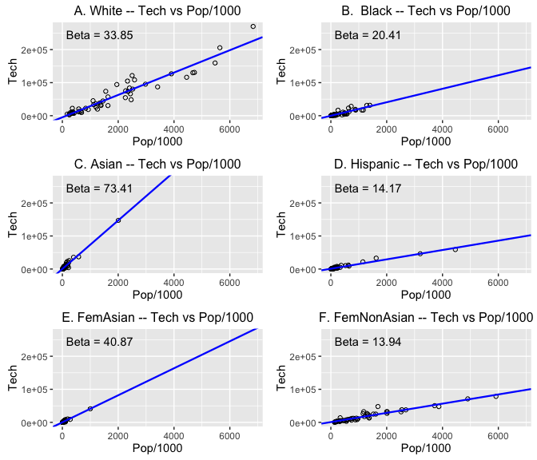

**Comments about Plots 5A, 5B, 5C, 5D, 5E, 5F**

[back-to-top](https://archimedes2kxx.github.io/BestStatesForBlackTech/Report-3.html)

**Table 5 – Summary of Parity Values for American Groups**

```
                 Tech perT Population perP  Par beta1000
White       2,916,852 71.7 93,526,664 69.0 1.04    33.85
Black         314,497  7.7 15,743,152 11.6 0.66    20.41
Asian         443,434 10.9  5,901,978  4.4 2.48    73.41
Hispanic      282,946  7.0 16,710,406 12.3 0.57    14.17
OTHERS        109,044  2.7  3,592,888  2.7 1.00    33.60
Female      1,039,074 25.6 65,027,346 48.0 0.53    16.28
FemAsian      128,871  3.2  2,931,010  2.2 1.45    40.87
FemNonAsian   910,203 22.4 62,096,336 45.8 0.49    13.94
```

**Comments about Table 5**

[back-to-top](https://archimedes2kxx.github.io/BestStatesForBlackTech/Report-3.html)

## *“And the best states are …”*

Which states were the best states for White, Black, Hispanic, Asian, and female American professionals in information technology? Given the limited scope of the data that I examined in this study, its selection criteria were rudimentary; so its conclusions should be regarded as tentative first approximations.

1. **Select states that had the largest number of techs in the racial/ethnic groups and the largest number Asian American females and non-Asian American females**  
   This criterion was implemented by selecting the states with the ten highest numbers of techs in each group, i.e., the states that appeared in short versions of Tables 4A through 4F.
2. **Select states that had parity values above each group’s median**  
   This criterion was implemented by identifying the states in Tables 4A through 4F that had state level parity values in the top 50% of all 50 states plus DC. Table 6 (below) summarizes the quartile breakdowns of the parity values for each group. For example, Table 6 shows the median Black parity value was 0.65; the median Hispanic parity value was 0.63.

*(Note that the first column in Table 6 shows the minimum non-zero parity values for each group. The PUMS sample for a few states had so few techs in some groups that the Census data could not provide reliable estimates of the number of techs in that state based on the sample, so missing values were set to zeros.)*

**Table 6 – Summary of Parity Values**

```
             Min   Q1 Median   Q3  Max
White       0.92 1.00   1.03 1.10 1.31
Black       0.23 0.53   0.65 0.80 5.71
Asian       0.46 1.47   2.21 2.89 5.68
Hispanic    0.13 0.50   0.63 0.82 1.44
Female      0.15 0.48   0.54 0.59 0.79
FemAsian    0.33 0.48   1.32 1.92 7.00
FemNonAsian 0.15 0.47   0.50 0.57 0.75
```

3. **Identify the finalists**  
   Table 7A through 7F lists the states whose parity values were greater than or equal to the median parity value for each group.

**Tables 7A, 7B, 7C, 7D, 7E, 7F – Finalists**

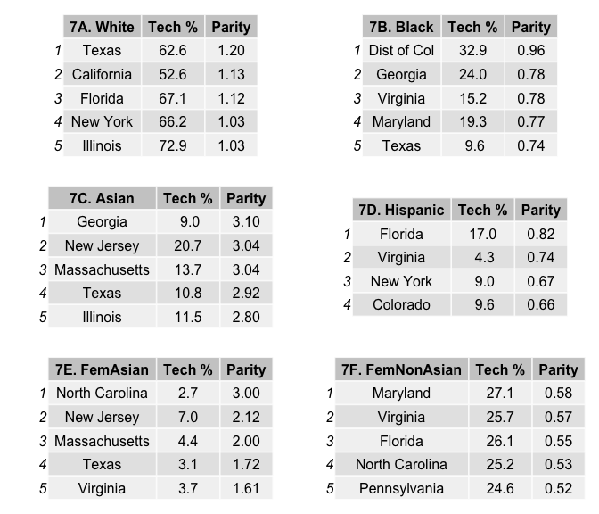

4. **Best States**  
   The “Best States” were chosen by sorting the finalists in decreasing order of each group’s percentage share (perT) of the tech sector. The state at the top of each list was the best of the best for its group, the state in the second row was the second best, and so on.

**Tables 8A, 8B, 8C, 8D, 8E, 8F – Best States for Americans in Tech**

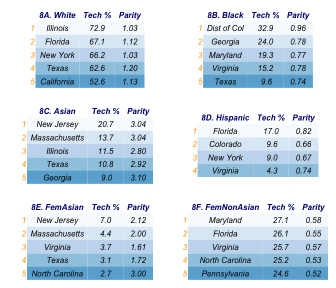

[back-to-top](https://archimedes2kxx.github.io/BestStatesForBlackTech/Report-3.html)

## Final Comments

Parity was a crude measure of the opportunities in tech that states provided to the groups considered in this study. Nevertheless, this simple metric suggested which groups should be broken into subgroups in order to obtain more useful insights.

**American Female vs. American Female**  
The low betas and national parity values in Table 5 that were assigned to American female techs (16.28 and 0.53) compared to the high betas and national parity values assigned to Asian American techs as a whole (73.41 and 2.48) suggested that that the American female category be broken into its Asian vs. non-Asian components, as per Tables 4E and 4F.

- As shown in Tables 5, the betas and national parity values for Asian American females (40.87 and 1.45) were much higher than the values for non-Asian females (13.94 and 0.49). In other words, Asian American females received substantially greater employment opportunities than non-Asian American females all over the country.
- This is not to say that tech treated Asian American males and Asian American females the same. Not at all. The betas and national parity values assigned to Asian Americans as a whole (73.41 and 2.48) were much higher than the values assigned to Asian females (40.87 and 1.45). Therefore the values assigned to Asian American males would have to be much higher than the values assigned to Asian American females, an indication that Asian American males received substantially greater employment opportunities per capita than Asian American females.

  [back-to-top](https://archimedes2kxx.github.io/BestStatesForBlackTech/Report-3.html)

**Hispanic American vs. Hispanic American**  
As shown in Table 4D, California employed the largest number of Hispanic Americans (58,879), Texas employed the second largest (46,261), and Florida employed the third largest number (32,968). Nevertheless Florida was the “Best State” for Hispanic Americans, whereas California and Texas didn’t make it into the top 3. Indeed Florida had the highest parity value, (0.82), of the ten biggest states in Table 4D, and its parity value was in the top quartile for all 50 states plus the District of Columbia, as shown in Table 6.

- In most states, being in tech means working in the information technology sections of government agencies or private corporations in various industries; whereas in California and to a lesser extent in Texas, a substantial number of techs work for computer companies. A large part of the Hispanic American workforce in Florida has Cuban ancestry; whereas large parts of the Hispanic American workforce in California and Texas have Mexican ancestry. Cuban entrepreneurs have established so many prominent businesses in Florida that Miami is often called the “financial capital” of Latin America,
- So it seems reasonable to conjecture that Cuban American tech professionals would have encountered fewer hiring obstacles in Florida because they “looked like/sounded like” many corporate owner/managers; but the same could not be said for Mexican American tech professionals in Texas or in California, and especially in Silicon Valley.

  [back-to-top](https://archimedes2kxx.github.io/BestStatesForBlackTech/Report-3.html)

**Black American vs. Black American**  
Table 5 showed that 11.6 percent of the total U.S. workforce in 2015 was Black American; and Table 5 also showed that the nation’s 314,497 Black American tech professionals represented 7.7 percent of the nation’s 4,066,773 American tech professionals.

- Table 5 showed that the national parity rating for Black Americans in tech was 0.66, i.e., 7.7 divided by 11.6, which was more than half, i.e., greater than 0.50. The vast majority of tech jobs required bachelors degrees. This meant that, contrary to popular misconceptions, the nation’s Black academic pipelines were more than half-full.
- According to Table 8B, the best states for Black American tech professionals were Dist of Col, Georgia, Maryland, Virginia, and Texas. These states weren’t just Southern states; they were HBCU states, homes to the **[Historically Black Colleges and Universities (HBCUs)](http://hbcu-levers.blogspot.com/p/hbcu-lists-profiles-2015.html)** that educated the overwhelming majority of Black college graduates before the Supreme Court’s desegregation decision in 1954 and the Civil Rights legislation in 1964/65. To this day, when over 90 percent of Black American students attend non-HBCUs, HBCUs still educate a large, disproportionate share of the nation’s Black American graduates in the STEM majors that provide entry into careers in information technology. (See my previous note on this blog **[HBCUs – the Best Producers of Black Graduates in STEM](http://hbcu-levers.blogspot.com/p/using-data-from-ipeds-data-center-this.html)**)
- Most people attend colleges that are no more than a few hundred miles from their homes, so the children of HBCU graduates have obtained STEM degrees from some of nation’s best colleges located in the HBCU states, e.g, Georgia Tech, Emory, Duke, Chapel Hill, and Austin. The presence of so many older Black techs in these states created dense, overlapping support networks of role models, mentors, and tutors for Black tech students and young Black tech graduates, networks that were reinforced by memberships in fraternities, sororities, churches, and other social groups, networks that facilitated their entry into the job market and subsequent promotion, networks that were not available to young Black techs in California and other non-HBCU states.

  [back-to-top](https://archimedes2kxx.github.io/BestStatesForBlackTech/Report-3.html)

**Asian American vs. Black American**  
*Question:* How did Asian American tech professionals attain such high parity values in every state?

- Table 4B shows that Black Americans have made good use of the expanded education and employment opportunities provided by the Supreme Court’s 1954 decision and the Civil Rights legislation that followed. But Black American academic pipelines are only half full because we are still overcoming the persistent evil legacy of hundreds of years of slavery and the decades of Jim Crow segregation that followed.
- Fortunately for Asian Americans, the oppression they faced before the Supreme Court and Congress outlawed racial exclusions from education and the workplace was orders of magnitude less debilitating. So facing lesser obstacles, Asian Americans have attained greater gains.
- Indeed, the remarkable success of Asian Americans in tech’s academic pipelines and subsequent employment reinvigorates the old ideal of America as a “Land of Opportunity”. For example, as per Table 1B, Asians were only 4.4 percent of the nation’s workforce in 2015. But according to U.S. Department of Education, Asian undergraduate enrollments at **[Cal Tech](http://nces.ed.gov/collegenavigator/?q=California+Institute+of+Technology&s=all&id=110404#enrolmt)** and **[M.I.T.](http://nces.ed.gov/collegenavigator/?q=Massachusetts+Institute+of+Technology&s=all&id=166683)** – arguably the best technical institutions in the nation, if not the world – are 45 percent and 25 percent, respectively. No one gets admitted to these highly competitive institutions without being very smart and being very well prepared.
- While smarts and thorough preparation are usually sufficient to gain admission to the best colleges and universities, being hired for the best jobs can also be a function of who you know … or more precisely, as Granovetter first observed in one of the most widely cited papers ever published (“**[The Strength of Weak Ties](https://en.wikipedia.org/wiki/Interpersonal_ties)**”), it’s who you know who knows someone who can hire you. So the more Asian Americans that were hired, the more indirect contacts other Asian Americans obtained.

  [back-to-top](https://archimedes2kxx.github.io/BestStatesForBlackTech/Report-3.html)

**American vs. Foreign**  
*Question:* How did foreign professionals obtain so many jobs in the U.S. tech sector?

- Foreign tech professionals had the strongest possible “weak ties” to their future employers because they had been proactively recruited by agents of U.S. companies who persuded them migrate to the U.S. in order to work for their U.S. clients in the U.S., primarily under the **[H-1B visa program](https://www.uscis.gov/eir/visa-guide/h-1b-specialty-occupation/understanding-h-1b-requirements)**
- I am currently developing a supplement to this report – “Best States for Foreign Professionals in U.S. Tech” – that will provide data that focuses on the increasing employment of foreign techs, especially in California. Thereafter I will post a companion op-ed on this blog – *“Why Are There So Many Foreign Techs in U.S. tech?*” – that will offer a plausible answer to the question in its title based on the data compiled for this report and data gathered from other sources.

[back-to-top](https://archimedes2kxx.github.io/BestStatesForBlackTech/Report-3.html)

## Personal Motivation

As the DLL Editor, my motivation for conducting this study influenced my methods. The recent barrage of **[annual reports](https://techcrunch.com/tag/diversity-report/)** from some of the nation’s leading information technology companies in Silicon Valley said the primary reason why those companies employed so few Black, Hispanic, and female information technology professionals was because there were so few available. And the reason they weren’t available was because there were so few Black, Hispanic, and female tech students in the nation’s academic pipelines.

**A. Best Practices**  
While reading the Silicon Valley reports I found myself wondering, “What numbers did they have to back up these assertions? And where did they get them from?” Whereas I would have said that the pipelines were half-full, these reports implied that the pipelines were perilously close to empty. But if the pipelines were close to empty, there shouldn’t be many Black, Hispanic, or female employees in the U.S. tech sector. This led me to wonder how many Black, Hispanic, and female techs were out there and where they were located.

**What concerned me the most was the lack of context for assessing Silicon Valley’s diversity numbers. Were they as good as could be expected? Were they worse? … And compared to what?** Compared to other states in other parts of the country? The personal data that I had accumulated from more than 50 years in tech informed me that tech was much more diverse in the Eastern and Southern states. But personal data, while a useful source of productive hypotheses, does not provide credible, systematic proof. As a clever tech pundit recently proclaimed, *“The plural of personal anecdote is not data” … :-)*

One of the most useful lessons that I learned as a consultant to the National Center for Productivity way back in the late 1970s was that the application of performance metrics, even flawed metrics, to just about any significant human activity invariably identified a broad middle tier that was above a small tier of low performers and below another small tier of high performers. Further inquiry usually disclosed that the high performers were doing things quite differently than the middle and low performers. Happily, performers in the lower tiers could improve by adopting the high performers’ best practices provided that they made appropriate adaptations of the best practices to their local conditions. Given this insight, I set out to apply a simple measure of the performance of all 50 states and the District of Columbia with regards to the opportunities their tech sectors provided for Black, Hispanic, and female professionals.

**B. Reproducible Reports**  
One of my most important take-aways from completing the **[Johns Hopkins “Data Science”](https://www.coursera.org/specializations/jhu-data-science)** online certificate program a few months ago was the notion that reports should be “reproducible”. Authors should not only describe their methods for collecting and analyzing data; they should provide step-by-step descriptions of their methods (including copies of their code) so that interested readers could readily reproduce the results on their own computers. Of course, the best researchers have always tried to achieve this objective and have often succeeded. What was new for me was the specific tools that the statisticians who taught the Hopkins courses recommended ==> the **[R programming language](https://en.wikipedia.org/wiki/R_)** and **GitHub**.

- Data should be downloaded from original sources, then analyzed, tabulated, mapped, and graphed via programs writen in R. Findings should be summarized in text laid out in a subset of **Markdown** that an R application called **[“knitr”](http://kbroman.org/knitr_knutshell/pages/Rmarkdown.html)** would convert to HTML pages suitable for publication on Websites.
- Reproducible reports should be as concise as traditional reports, but the writer’s notes, programs, analytical tools, coding guides, data files, tables, maps, and graphs should be shared with the world via GitHub repositories.

Of course Python, MATLAB, or other comparable languages could be used instead of R, and the supplementary files could be stored on other public repositories comparable to GitHub. This being my first attept to write a reproducible report, I wrote it in R and stored my supporting files in a public GitHub repo. If readers disagree with my numbers, they won’t have to wonder how I got them *… #OldDogStillLearningNewTricks … :-)*

[back-to-top](https://archimedes2kxx.github.io/BestStatesForBlackTech/Report-3.html)

## Methods

I used the U.S. Census Bureau’s **[DataFerret](http://thedataweb.rm.census.gov/index.html)** Java application to download two pairs of samples from the Public Use Microdata Sample (PUMS) from the Bureau’s American Community Survey for 2010 and 2015. The first pair of samples was used to estimate the size of the White, Black, Asian, Hispanic, and female components of the total workforce in each of the 50 states plus the District of Columbia in 2010 and 2015

The second, more detailed pair of samples was used to estimate the size of the corresponding components of the tech subset of the total workforce in 2010 and 2015. The number of observations in each of the second pair of samples was usually large enough to make good estimates of the employee counts and percentages of tech employment for Blacks, Whites, Asians, and Hispanics in tech occupations in the 50 states and DC. (*Note: For a few states with small tech populations, the ACS subset included missing values which meant that it wasn’t large enough to provide reliable estimates of the racial/ethnic breakdown of tech employment in those states*. Missing values were converted to zeros in these cases.) My step-by-step procedures for selecting and downloading the ACS data and its codebook is described in **[Notes-Data-Download-PUMS-Sample](https://archimedes2kxx.github.io/BestStatesForBlackTech/Notes-Data-Download-PUMS-Sample.html)** on the **[GitHub repo](https://github.com/Archimedes2kxx/BestStatesForBlackTech)**. (*Note: the GitHub repo page should be opened in a separate window, not in the iFrame on the Tech-Levers blog.)*

**Selected Data**

- **Occupation**  
  When using the DataFerret app to select a sample of tech professionals from the full PUMS 2010 and 2015 samples, I defined the “information technology sector” by designating the 13 standard occupational categories shown in tables displayed in the answers to **[Question 3](https://archimedes2kxx.github.io/BestStatesForBlackTech/Report-3.html#question-3-how-did-the-racial-ethnic-foreign-and-malefemale-shares-of-the-job-categories-in-u.s.-tech-change-between-2010-and-2015)**. Twelve categories were software, one was hardware
- **Hispanic vs White (not Hispanic), Black (not Hispanic), Asian (not Hispanic)**  
  I configured the DataFerret to include all races in my sample. However, Hispanic is not regarded as a race, but as an ethnic/national origin, like being Irish, Egyptian, Japanese, or Nigerian. So I included the “Hispanic” variable. This variable designated each respondent’s Hispanic origin, e.g., Mexico, Chile, Puerto Rico, etc … but it also contained a “Not Hispanic” value for respondents who were not descended from Hispanic countries. Using this code, I distinguished between “White” vs. “White (not Hispanic)”, “Black” vs. “Black (not Hispanic)”, and “Asian” vs. “Asian (not Hispanic)” and “Others” vs “Others (non-Hispanic)”. Accordingly, my report contains data about four racial/ethnic groups: Hispanic, White (not Hispanic), Black (not Hispanic), and Asian (not Hispanic); but for brevity it merely calls them Hispanic, White, Black, and Asian.
- **Estimating population values from the sample**  
  Each row in the downloaded PUMS tables contained the anonymized responses of a real employee in the ACS 2010 and 2015 surveys, i.e., sex, race/ethnicity, occupation, and state of Workplace. Each observation also contained a number called “personal weight” which is the Census Bureau’s estimate of how many people in the real population were like each person in the sample. An estimate of the total number of employees in the real population was found by adding up the personal weights of the employees in the sample. This also applied to subgroups, e.g, male vs. female, state of Workplace, etc. The percentage share of a subgroup’s workforce was obtained by dividing the estimated workforce in the subgroup by the estimated workforce in the entire group, i.e., dividing the sum of personal weights in a subgroup by the sum of personal weights in the larger group.  
  Here’s the **[Census Bureau’s description](https://usa.ipums.org/usa/voliii/ACSsamp.shtml)** of this process:  
  *“Production of Estimates”* – The ACS PUMS sample is not self - weighted. To produce estimates or tabulations of characteristics from the ACS PUMS simply add the weights of all persons or housing units that possess the characteristic of interest. For instance, if the characteristic of interest is “total number of black teachers”, simply determine the race and occupation of all persons and cumulate the weights of those who match the characteristics of interest. To get estimates of proportions simply divide the weighted estimate of persons or housing units with a given characteristic by the weighted estimate of the base. For example, the proportion of “black teachers” is obtained by dividing the weighted estimate of black teachers by the PUMS estimate of teachers."

I used the **[R Studio IDE](https://www.rstudio.com/)** to write the R scripts and functions that produced the report’s tables, maps, graphs, and stats. My R code can be found in the functions-0.R, Data-1.R, Stats-2A.R, Stats-2B.R, Stats-2C.R., and Report-3.Rmd files in the **[Best States](https://github.com/Archimedes2kxx/BestStatesForBlackTech)** repo, as well as copies of the codebooks and .csv files I downloaded from the Census. I composed the text of the report in R-Markdown, embedded the data objects, converted the R-markdown to HTML via knitr, pushed the report to git-io pages, then made the pages accessible to readers of the DLL’s **[Tech-Levers](http://hbcu-levers.blogspot.com/p/draft-of-best-states-for-blacks-in-tech.html)** blog via an iframe on a page on the blog.

The scripts and embedded functions should be loaded in numerical order ==> functions-0.R then Data-1.R The Data-1.R module uses the functions to read the Census data files, then create the data frames required by Stats-2A.R, Stats-2B.R, and Stats-2C.R. The Stats modules use the functions to create the tables, maps, graphs, and regressions required by the R-markdown script in the Report-3.Rmd file that generates the report.

Finally, this report represents my honest attempt to shed additional light on some important, troublesome issues. Therefore I would greatly appreciate readers’ comments and suggested improvements … but I would cherish their help in identifying any errors that I made in my data collection or analysis because bad reports don’t support good policies. Thank you … :-)

[back-to-top](https://archimedes2kxx.github.io/BestStatesForBlackTech/Report-3.html)

## Appendix – Profiles of Tech Sector Jobs in the Six Biggest Tech States plus Washington, DC in 2015

As per Table 4 in the report, the first six states in this appendix employed the largest number of Americans in their tech sectors – California, Texas, New York, Florida, Virginia, and Illinois. The District of Columbia was also included because it was identified in Table 8B as the **[Best State](https://archimedes2kxx.github.io/BestStatesForBlackTech/Report-3.html#and-the-best-states-are)** for Black Americans in tech.

Three pairs of tables are included for each state:

- The first two tables show changes in the employement of American citizens between 2010 and 2015 in the state’s tech sector.
- The second pair of tables show changes in employment of Black Americans between 2010 and 2015 in the state’s tech sector.
- The third pair of tables show change in employment of Hispanic Americans between 2010 and 2015 in the state’s tech sector.

In a future version of this report, this Appendix will be replaced by an interactive dashboard that will allow users to display pairs of tables for any state and for any American or foreign group.

*Note: The column headings and abbreviated row names of the tables in this appendix are explained in the answer to [**Question 3**](https://archimedes2kxx.github.io/BestStatesForBlackTech/Report-3.html#question-3-how-did-the-racial-ethnic-foreign-and-malefemale-shares-of-the-job-categories-in-u.s.-tech-change-between-2010-and-2015) in the body of the report.*

### California … California …California … California … California …

**Table 3.CA – American Male/Female Tech in California in 2015**

```
                     Occupation perTS  Tech15     Fem perF15
                All Occupations 100.0 513,031 119,597   23.3
            SOFTWARE DEVELOPERS  30.1 154,590  30,563   19.8
   COMPUTER SUPPORT SPECIALISTS  12.5  64,055  13,969   21.8
 COMPUTER/INFO SYSTEMS MANAGERS  11.2  57,446  17,617   30.7
      COMPUTER SYSTEMS ANALYSTS   9.9  50,927  18,547   36.4
           COMPUTER PROGRAMMERS   9.7  49,869   7,744   15.5
 COMPUTER OCCUPATIONS ALL OTHER   9.7  49,770  10,902   21.9
                 WEB DEVELOPERS   4.9  25,128   8,833   35.2
    NETWORK/COMP SYSTEMS ADMINS   3.8  19,632   3,231   16.5
    COMPUTER NETWORK ARCHITECTS   3.0  15,341   1,395    9.1
        DATABASE ADMINISTRATORS   1.9   9,878   3,937   39.9
    COMPUTER HARDWARE ENGINEERS   1.8   9,363   1,388   14.8
  INFORMATION SECURITY ANALYSTS   0.9   4,868     868   17.8
  COMP/INFO RESEARCH SCIENTISTS   0.4   2,164     603   27.9
```

**Table 3.CACA – Changes in American Tech in California 2010 to 2015**

```
                     Occupation  Tech10  Tech15  Change perCh perF10
                All Occupations 403,554 513,031 109,477  27.1   24.7
            SOFTWARE DEVELOPERS 103,979 154,590  50,611  48.7   21.2
   COMPUTER SUPPORT SPECIALISTS  41,983  64,055  22,072  52.6   23.8
 COMPUTER/INFO SYSTEMS MANAGERS  57,132  57,446     314   0.5   29.6
      COMPUTER SYSTEMS ANALYSTS  44,473  50,927   6,454  14.5   37.8
           COMPUTER PROGRAMMERS  50,463  49,869    -594  -1.2   21.0
 COMPUTER OCCUPATIONS ALL OTHER  29,657  49,770  20,113  67.8   16.6
                 WEB DEVELOPERS  21,866  25,128   3,262  14.9   33.7
    NETWORK/COMP SYSTEMS ADMINS  23,622  19,632  -3,990 -16.9   16.9
    COMPUTER NETWORK ARCHITECTS   7,416  15,341   7,925 106.9   10.6
        DATABASE ADMINISTRATORS   9,200   9,878     678   7.4   39.8
    COMPUTER HARDWARE ENGINEERS   9,403   9,363     -40  -0.4   15.5
  INFORMATION SECURITY ANALYSTS   2,425   4,868   2,443 100.7   25.4
  COMP/INFO RESEARCH SCIENTISTS   1,935   2,164     229  11.8   25.1
```

[back-to-top](https://archimedes2kxx.github.io/BestStatesForBlackTech/Report-3.html)

**Table 3.CAblack – Black American Male/Female Tech in California in 2015**

```
                     Occupation perTS Tech15   Fem perF15
                All Occupations 100.0 19,068 5,603   29.4
   COMPUTER SUPPORT SPECIALISTS  23.5  4,488 1,888   42.1
      COMPUTER SYSTEMS ANALYSTS  17.8  3,403 1,581   46.5
 COMPUTER/INFO SYSTEMS MANAGERS  12.2  2,334   766   32.8
 COMPUTER OCCUPATIONS ALL OTHER  11.4  2,171   203    9.4
            SOFTWARE DEVELOPERS   9.9  1,885   196   10.4
    COMPUTER NETWORK ARCHITECTS   7.7  1,461    72    4.9
           COMPUTER PROGRAMMERS   5.9  1,127   234   20.8
                 WEB DEVELOPERS   4.9    939   275   29.3
        DATABASE ADMINISTRATORS   4.0    760   388   51.1
    COMPUTER HARDWARE ENGINEERS   1.0    199     0    0.0
    NETWORK/COMP SYSTEMS ADMINS   0.9    172     0    0.0
  INFORMATION SECURITY ANALYSTS   0.7    129     0    0.0
  COMP/INFO RESEARCH SCIENTISTS   0.0      0     0    0.0
```

**Table 3.CACAblack – Changes in Black American Tech in California 2010 to 2015**

```
                     Occupation Tech10 Tech15 Change  perCh perF10
                All Occupations 16,971 19,068  2,097   12.4   24.8
   COMPUTER SUPPORT SPECIALISTS  1,943  4,488  2,545  131.0    7.1
      COMPUTER SYSTEMS ANALYSTS  3,151  3,403    252    8.0   32.7
 COMPUTER/INFO SYSTEMS MANAGERS  2,909  2,334   -575  -19.8   40.1
 COMPUTER OCCUPATIONS ALL OTHER  2,373  2,171   -202   -8.5    3.6
            SOFTWARE DEVELOPERS  1,688  1,885    197   11.7   21.9
    COMPUTER NETWORK ARCHITECTS    163  1,461  1,298  796.3    0.0
           COMPUTER PROGRAMMERS  1,511  1,127   -384  -25.4   40.1
                 WEB DEVELOPERS    421    939    518  123.0   21.1
        DATABASE ADMINISTRATORS    554    760    206   37.2   11.4
    COMPUTER HARDWARE ENGINEERS    382    199   -183  -47.9   19.9
    NETWORK/COMP SYSTEMS ADMINS  1,422    172 -1,250  -87.9   15.4
  INFORMATION SECURITY ANALYSTS    366    129   -237  -64.8   77.3
  COMP/INFO RESEARCH SCIENTISTS     88      0    -88 -100.0  100.0
```

[back-to-top](https://archimedes2kxx.github.io/BestStatesForBlackTech/Report-3.html)

**Table 3.CAhispanic – Hispanic American Male/Female Tech in California in 2015**

```
                     Occupation perTS Tech15    Fem perF15
                All Occupations 100.0 58,879 14,999   25.5
   COMPUTER SUPPORT SPECIALISTS  20.9 12,334  2,396   19.4
            SOFTWARE DEVELOPERS  16.1  9,500  1,761   18.5
 COMPUTER OCCUPATIONS ALL OTHER  15.4  9,084  2,257   24.8
      COMPUTER SYSTEMS ANALYSTS  11.8  6,955  2,377   34.2
 COMPUTER/INFO SYSTEMS MANAGERS   8.3  4,901  1,833   37.4
                 WEB DEVELOPERS   6.5  3,825  1,672   43.7
    NETWORK/COMP SYSTEMS ADMINS   6.0  3,517    440   12.5
           COMPUTER PROGRAMMERS   5.7  3,360    857   25.5
    COMPUTER NETWORK ARCHITECTS   3.9  2,296    238   10.4
    COMPUTER HARDWARE ENGINEERS   2.1  1,232    713   57.9
        DATABASE ADMINISTRATORS   1.8  1,048    293   28.0
  INFORMATION SECURITY ANALYSTS   1.4    827    162   19.6
  COMP/INFO RESEARCH SCIENTISTS   0.0      0      0    0.0
```

**Table 3.CACAhispanic – Changes in Hispanic American Tech in California 2010 to 2015**

```
                     Occupation Tech10 Tech15 Change perCh perF10
                All Occupations 32,820 58,879 26,059  79.4   27.0
   COMPUTER SUPPORT SPECIALISTS  4,989 12,334  7,345 147.2   28.3
            SOFTWARE DEVELOPERS  5,286  9,500  4,214  79.7   18.3
 COMPUTER OCCUPATIONS ALL OTHER  4,667  9,084  4,417  94.6   21.4
      COMPUTER SYSTEMS ANALYSTS  4,086  6,955  2,869  70.2   53.3
 COMPUTER/INFO SYSTEMS MANAGERS  3,674  4,901  1,227  33.4   36.1
                 WEB DEVELOPERS  1,422  3,825  2,403 169.0   26.4
    NETWORK/COMP SYSTEMS ADMINS  2,038  3,517  1,479  72.6    6.4
           COMPUTER PROGRAMMERS  3,767  3,360   -407 -10.8   29.5
    COMPUTER NETWORK ARCHITECTS    912  2,296  1,384 151.8    0.0
    COMPUTER HARDWARE ENGINEERS    801  1,232    431  53.8   20.1
        DATABASE ADMINISTRATORS    909  1,048    139  15.3   15.0
  INFORMATION SECURITY ANALYSTS    269    827    558 207.4   21.9
  COMP/INFO RESEARCH SCIENTISTS      0      0      0   NaN    0.0
```

[back-to-top](https://archimedes2kxx.github.io/BestStatesForBlackTech/Report-3.html)

### Texas … Texas … Texas … Texas … Texas … Texas … Texas …

**Table 3.TX – American Male/Female Tech in Texas in 2015**

```
                     Occupation perTS  Tech15    Fem perF15
                All Occupations 100.0 328,635 81,307   24.7
            SOFTWARE DEVELOPERS  20.8  68,305 14,562   21.3
   COMPUTER SUPPORT SPECIALISTS  16.3  53,409 13,519   25.3
 COMPUTER OCCUPATIONS ALL OTHER  14.4  47,318 11,636   24.6
 COMPUTER/INFO SYSTEMS MANAGERS  13.4  44,156 10,923   24.7
      COMPUTER SYSTEMS ANALYSTS  10.5  34,598 13,502   39.0
           COMPUTER PROGRAMMERS   8.6  28,301  4,890   17.3
    NETWORK/COMP SYSTEMS ADMINS   4.8  15,891  3,101   19.5
                 WEB DEVELOPERS   3.6  11,905  4,450   37.4
    COMPUTER NETWORK ARCHITECTS   2.8   9,212  1,088   11.8
        DATABASE ADMINISTRATORS   2.0   6,696  2,542   38.0
  INFORMATION SECURITY ANALYSTS   1.9   6,224    607    9.8
    COMPUTER HARDWARE ENGINEERS   0.5   1,795    110    6.1
  COMP/INFO RESEARCH SCIENTISTS   0.3     825    377   45.7
```

**Table 3.TXTX – Changes in American Tech in Texas 2010 to 2015**

```
                     Occupation  Tech10  Tech15 Change perCh perF10
                All Occupations 261,026 328,635 67,609  25.9   25.8
            SOFTWARE DEVELOPERS  48,308  68,305 19,997  41.4   20.1
   COMPUTER SUPPORT SPECIALISTS  47,218  53,409  6,191  13.1   26.7
 COMPUTER OCCUPATIONS ALL OTHER  19,494  47,318 27,824 142.7   25.4
 COMPUTER/INFO SYSTEMS MANAGERS  33,424  44,156 10,732  32.1   30.6
      COMPUTER SYSTEMS ANALYSTS  34,302  34,598    296   0.9   37.0
           COMPUTER PROGRAMMERS  31,589  28,301 -3,288 -10.4   18.0
    NETWORK/COMP SYSTEMS ADMINS  14,817  15,891  1,074   7.2   19.4
                 WEB DEVELOPERS   9,231  11,905  2,674  29.0   29.4
    COMPUTER NETWORK ARCHITECTS   6,626   9,212  2,586  39.0   11.8
        DATABASE ADMINISTRATORS   7,249   6,696   -553  -7.6   34.8
  INFORMATION SECURITY ANALYSTS   3,565   6,224  2,659  74.6   26.3
    COMPUTER HARDWARE ENGINEERS   3,982   1,795 -2,187 -54.9   20.1
  COMP/INFO RESEARCH SCIENTISTS   1,221     825   -396 -32.4   74.1
```

[back-to-top](https://archimedes2kxx.github.io/BestStatesForBlackTech/Report-3.html)

**Table 3.TXblack – Black American Male/Female Tech in Texas in 2015**

```
                     Occupation perTS Tech15    Fem perF15
                All Occupations 100.0 31,437 11,489   36.5
   COMPUTER SUPPORT SPECIALISTS  27.3  8,583  2,275   26.5
 COMPUTER OCCUPATIONS ALL OTHER  17.6  5,530  1,991   36.0
            SOFTWARE DEVELOPERS  13.6  4,268  1,180   27.6
      COMPUTER SYSTEMS ANALYSTS  12.6  3,964  2,935   74.0
 COMPUTER/INFO SYSTEMS MANAGERS  10.2  3,208  1,222   38.1
                 WEB DEVELOPERS   4.1  1,284    946   73.7
           COMPUTER PROGRAMMERS   3.8  1,208    456   37.7
  INFORMATION SECURITY ANALYSTS   3.2    993    171   17.2
    NETWORK/COMP SYSTEMS ADMINS   2.7    861      0    0.0
        DATABASE ADMINISTRATORS   2.5    786    134   17.0
    COMPUTER NETWORK ARCHITECTS   2.1    663    179   27.0
    COMPUTER HARDWARE ENGINEERS   0.3     89      0    0.0
  COMP/INFO RESEARCH SCIENTISTS   0.0      0      0    0.0
```

**Table 3.TXTXblack – Changes in Black American Tech in Texas 2010 to 2015**

```
                     Occupation Tech10 Tech15 Change  perCh perF10
                All Occupations 18,942 31,437 12,495   66.0   37.7
   COMPUTER SUPPORT SPECIALISTS  5,558  8,583  3,025   54.4   39.7
 COMPUTER OCCUPATIONS ALL OTHER  1,885  5,530  3,645  193.4   56.0
            SOFTWARE DEVELOPERS  1,376  4,268  2,892  210.2   17.2
      COMPUTER SYSTEMS ANALYSTS  3,824  3,964    140    3.7   40.8
 COMPUTER/INFO SYSTEMS MANAGERS  1,737  3,208  1,471   84.7   30.7
                 WEB DEVELOPERS    806  1,284    478   59.3   39.3
           COMPUTER PROGRAMMERS  1,310  1,208   -102   -7.8   17.8
  INFORMATION SECURITY ANALYSTS    650    993    343   52.8   69.5
    NETWORK/COMP SYSTEMS ADMINS    500    861    361   72.2   13.4
        DATABASE ADMINISTRATORS    568    786    218   38.4   48.8
    COMPUTER NETWORK ARCHITECTS    372    663    291   78.2    0.0
    COMPUTER HARDWARE ENGINEERS      0     89     89    Inf    0.0
  COMP/INFO RESEARCH SCIENTISTS    356      0   -356 -100.0   57.3
```

[back-to-top](https://archimedes2kxx.github.io/BestStatesForBlackTech/Report-3.html)

**Table 3.TXhispanic – Hispanic American Male/Female Tech in Texas in 2015**

```
                     Occupation perTS Tech15    Fem perF15
                All Occupations 100.0 46,261 11,594   25.1
   COMPUTER SUPPORT SPECIALISTS  21.9 10,129  2,834   28.0
 COMPUTER OCCUPATIONS ALL OTHER  19.0  8,782  2,133   24.3
            SOFTWARE DEVELOPERS  14.9  6,879  1,664   24.2
      COMPUTER SYSTEMS ANALYSTS  11.4  5,252  1,891   36.0
 COMPUTER/INFO SYSTEMS MANAGERS   9.2  4,249    901   21.2
    NETWORK/COMP SYSTEMS ADMINS   8.4  3,880    816   21.0
           COMPUTER PROGRAMMERS   5.6  2,592    312   12.0
                 WEB DEVELOPERS   3.6  1,654    372   22.5
    COMPUTER NETWORK ARCHITECTS   2.0    918    356   38.8
        DATABASE ADMINISTRATORS   1.6    763    229   30.0
  INFORMATION SECURITY ANALYSTS   1.1    525     36    6.9
  COMP/INFO RESEARCH SCIENTISTS   0.8    390     50   12.8
    COMPUTER HARDWARE ENGINEERS   0.5    248      0    0.0
```

**Table 3.TXTXhispanic – Changes in Hispanic American Tech in TExas 2010 to 2015**

```
                     Occupation Tech10 Tech15 Change perCh perF10
                All Occupations 37,149 46,261  9,112  24.5   24.6
   COMPUTER SUPPORT SPECIALISTS 10,156 10,129    -27  -0.3   21.4
 COMPUTER OCCUPATIONS ALL OTHER  3,154  8,782  5,628 178.4   19.7
            SOFTWARE DEVELOPERS  5,088  6,879  1,791  35.2   29.7
      COMPUTER SYSTEMS ANALYSTS  3,921  5,252  1,331  33.9   40.3
 COMPUTER/INFO SYSTEMS MANAGERS  3,286  4,249    963  29.3   29.1
    NETWORK/COMP SYSTEMS ADMINS  2,997  3,880    883  29.5   17.2
           COMPUTER PROGRAMMERS  4,373  2,592 -1,781 -40.7   22.6
                 WEB DEVELOPERS  1,191  1,654    463  38.9    1.4
    COMPUTER NETWORK ARCHITECTS    693    918    225  32.5   11.0
        DATABASE ADMINISTRATORS  1,125    763   -362 -32.2   14.2
  INFORMATION SECURITY ANALYSTS    526    525     -1  -0.2   41.3
  COMP/INFO RESEARCH SCIENTISTS    305    390     85  27.9  100.0
    COMPUTER HARDWARE ENGINEERS    334    248    -86 -25.7    0.0
```

[back-to-top](https://archimedes2kxx.github.io/BestStatesForBlackTech/Report-3.html)

### New York … New York … New York … New York …

**Table 3.NY – American Male/Female Tech in New York in 2015**

```
                     Occupation perTS  Tech15    Fem perF15
                All Occupations 100.0 240,885 56,652   23.5
            SOFTWARE DEVELOPERS  18.0  43,378  7,333   16.9
   COMPUTER SUPPORT SPECIALISTS  14.4  34,799  8,196   23.6
      COMPUTER SYSTEMS ANALYSTS  12.8  30,898 10,715   34.7
 COMPUTER OCCUPATIONS ALL OTHER  12.6  30,397  6,420   21.1
 COMPUTER/INFO SYSTEMS MANAGERS  12.2  29,324  7,688   26.2
           COMPUTER PROGRAMMERS  11.7  28,158  6,621   23.5
                 WEB DEVELOPERS   5.7  13,849  4,810   34.7
    NETWORK/COMP SYSTEMS ADMINS   4.1   9,928  1,317   13.3
    COMPUTER NETWORK ARCHITECTS   3.0   7,240    205    2.8
        DATABASE ADMINISTRATORS   2.5   5,948  1,771   29.8
  INFORMATION SECURITY ANALYSTS   1.3   3,219  1,156   35.9
    COMPUTER HARDWARE ENGINEERS   1.0   2,368    284   12.0
  COMP/INFO RESEARCH SCIENTISTS   0.6   1,379    136    9.9
```

**Table 3.NYNY – Changes in American Tech in New York 2010 to 2015**

```
                     Occupation  Tech10  Tech15 Change perCh perF10
                All Occupations 200,259 240,885 40,626  20.3   25.4
            SOFTWARE DEVELOPERS  31,844  43,378 11,534  36.2   19.9
   COMPUTER SUPPORT SPECIALISTS  22,859  34,799 11,940  52.2   23.8
      COMPUTER SYSTEMS ANALYSTS  28,850  30,898  2,048   7.1   35.4
 COMPUTER OCCUPATIONS ALL OTHER  20,920  30,397  9,477  45.3   18.2
 COMPUTER/INFO SYSTEMS MANAGERS  24,694  29,324  4,630  18.7   31.1
           COMPUTER PROGRAMMERS  30,846  28,158 -2,688  -8.7   21.6
                 WEB DEVELOPERS  12,842  13,849  1,007   7.8   35.4
    NETWORK/COMP SYSTEMS ADMINS  12,450   9,928 -2,522 -20.3   20.6
    COMPUTER NETWORK ARCHITECTS   5,133   7,240  2,107  41.0    6.8
        DATABASE ADMINISTRATORS   4,340   5,948  1,608  37.1   45.0
  INFORMATION SECURITY ANALYSTS   2,152   3,219  1,067  49.6   30.8
    COMPUTER HARDWARE ENGINEERS   3,164   2,368   -796 -25.2   13.7
  COMP/INFO RESEARCH SCIENTISTS     165   1,379  1,214 735.8   52.7
```

[back-to-top](https://archimedes2kxx.github.io/BestStatesForBlackTech/Report-3.html)

**Table 3.NYblack – Black American Male/Female Tech in New York in 2015**

```
                     Occupation perTS Tech15   Fem perF15
                All Occupations 100.0 17,100 4,467   26.1
 COMPUTER OCCUPATIONS ALL OTHER  17.9  3,069   743   24.2
   COMPUTER SUPPORT SPECIALISTS  17.5  3,000 1,331   44.4
      COMPUTER SYSTEMS ANALYSTS  14.2  2,434   827   34.0
 COMPUTER/INFO SYSTEMS MANAGERS  12.8  2,188   475   21.7
            SOFTWARE DEVELOPERS   9.1  1,548   273   17.6
           COMPUTER PROGRAMMERS   8.8  1,509   599   39.7
                 WEB DEVELOPERS   7.0  1,202     0    0.0
        DATABASE ADMINISTRATORS   6.8  1,155   219   19.0
    COMPUTER NETWORK ARCHITECTS   3.8    654     0    0.0
    NETWORK/COMP SYSTEMS ADMINS   0.9    153     0    0.0
    COMPUTER HARDWARE ENGINEERS   0.7    120     0    0.0
  INFORMATION SECURITY ANALYSTS   0.4     68     0    0.0
  COMP/INFO RESEARCH SCIENTISTS   0.0      0     0    0.0
```

**Table 3.NYNYblack – Changes in Black American Tech in New York 2010 to 2015**

```
                     Occupation Tech10 Tech15 Change perCh perF10
                All Occupations 15,492 17,100  1,608  10.4   25.7
 COMPUTER OCCUPATIONS ALL OTHER  2,902  3,069    167   5.8   31.0
   COMPUTER SUPPORT SPECIALISTS  3,986  3,000   -986 -24.7   19.6
      COMPUTER SYSTEMS ANALYSTS  2,859  2,434   -425 -14.9   33.7
 COMPUTER/INFO SYSTEMS MANAGERS    939  2,188  1,249 133.0   29.1
            SOFTWARE DEVELOPERS  1,104  1,548    444  40.2   35.7
           COMPUTER PROGRAMMERS    690  1,509    819 118.7   24.6
                 WEB DEVELOPERS    640  1,202    562  87.8    0.0
        DATABASE ADMINISTRATORS    377  1,155    778 206.4    0.0
    COMPUTER NETWORK ARCHITECTS    350    654    304  86.9   38.9
    NETWORK/COMP SYSTEMS ADMINS  1,106    153   -953 -86.2   33.1
    COMPUTER HARDWARE ENGINEERS    162    120    -42 -25.9    0.0
  INFORMATION SECURITY ANALYSTS    377     68   -309 -82.0    0.0
  COMP/INFO RESEARCH SCIENTISTS      0      0      0   NaN    0.0
```

[back-to-top](https://archimedes2kxx.github.io/BestStatesForBlackTech/Report-3.html)

**Table 3.NYhispanic – Hispanic American Male/Female Tech in New York in 2015**

```
                     Occupation perTS Tech15   Fem perF15
                All Occupations 100.0 21,662 5,663   26.1
   COMPUTER SUPPORT SPECIALISTS  22.2  4,813 1,759   36.5
            SOFTWARE DEVELOPERS  17.7  3,832   414   10.8
 COMPUTER/INFO SYSTEMS MANAGERS  16.6  3,593 1,074   29.9
 COMPUTER OCCUPATIONS ALL OTHER  10.7  2,316     0    0.0
      COMPUTER SYSTEMS ANALYSTS   8.7  1,875 1,289   68.7
           COMPUTER PROGRAMMERS   6.5  1,399   206   14.7
    NETWORK/COMP SYSTEMS ADMINS   6.0  1,301   230   17.7
                 WEB DEVELOPERS   4.4    955   368   38.5
        DATABASE ADMINISTRATORS   2.4    516   171   33.1
    COMPUTER NETWORK ARCHITECTS   2.0    439     0    0.0
    COMPUTER HARDWARE ENGINEERS   1.1    234     0    0.0
  INFORMATION SECURITY ANALYSTS   0.9    201    55   27.4
  COMP/INFO RESEARCH SCIENTISTS   0.9    188    97   51.6
```

**Table 3.NYNYhispanic – Changes in Hispanic American Tech in New York 2010 to 2015**

```
                     Occupation Tech10 Tech15 Change perCh perF10
                All Occupations 12,681 21,662  8,981  70.8   27.9
   COMPUTER SUPPORT SPECIALISTS  1,652  4,813  3,161 191.3   16.9
            SOFTWARE DEVELOPERS    749  3,832  3,083 411.6   38.7
 COMPUTER/INFO SYSTEMS MANAGERS  2,308  3,593  1,285  55.7   43.8
 COMPUTER OCCUPATIONS ALL OTHER  2,417  2,316   -101  -4.2    1.2
      COMPUTER SYSTEMS ANALYSTS  1,858  1,875     17   0.9   44.6
           COMPUTER PROGRAMMERS    890  1,399    509  57.2   47.1
    NETWORK/COMP SYSTEMS ADMINS    987  1,301    314  31.8   15.7
                 WEB DEVELOPERS    552    955    403  73.0   26.4
        DATABASE ADMINISTRATORS    377    516    139  36.9   57.8
    COMPUTER NETWORK ARCHITECTS    364    439     75  20.6    0.0
    COMPUTER HARDWARE ENGINEERS    334    234   -100 -29.9   21.3
  INFORMATION SECURITY ANALYSTS    193    201      8   4.1   49.7
  COMP/INFO RESEARCH SCIENTISTS      0    188    188   Inf    0.0
```

[back-to-top](https://archimedes2kxx.github.io/BestStatesForBlackTech/Report-3.html)

### Florida … Florida … Florida … Florida …

**Table 3.FL – American Male/Female Tech in Florida in 2015**

```
                     Occupation perTS  Tech15    Fem perF15
                All Occupations 100.0 193,697 51,910   26.8
   COMPUTER SUPPORT SPECIALISTS  17.6  34,021 10,410   30.6
            SOFTWARE DEVELOPERS  16.9  32,703  6,518   19.9
 COMPUTER OCCUPATIONS ALL OTHER  14.8  28,670  7,890   27.5
 COMPUTER/INFO SYSTEMS MANAGERS  13.0  25,177  7,364   29.2
           COMPUTER PROGRAMMERS  10.1  19,519  4,203   21.5
      COMPUTER SYSTEMS ANALYSTS   8.9  17,209  6,176   35.9
                 WEB DEVELOPERS   5.8  11,212  4,849   43.2
    NETWORK/COMP SYSTEMS ADMINS   5.3  10,249  1,948   19.0
        DATABASE ADMINISTRATORS   2.6   4,973  1,598   32.1
    COMPUTER NETWORK ARCHITECTS   2.4   4,567    135    3.0
  INFORMATION SECURITY ANALYSTS   1.5   2,856    466   16.3
    COMPUTER HARDWARE ENGINEERS   1.1   2,158    295   13.7
  COMP/INFO RESEARCH SCIENTISTS   0.2     383     58   15.1
```

**Table 3.FLFL – Changes in American Tech in Florida 2010 to 2015**

```
                     Occupation  Tech10  Tech15 Change perCh perF10
                All Occupations 145,995 193,697 47,702  32.7   24.6
   COMPUTER SUPPORT SPECIALISTS  23,895  34,021 10,126  42.4   27.3
            SOFTWARE DEVELOPERS  27,357  32,703  5,346  19.5   21.2
 COMPUTER OCCUPATIONS ALL OTHER  14,017  28,670 14,653 104.5   20.4
 COMPUTER/INFO SYSTEMS MANAGERS  18,104  25,177  7,073  39.1   27.5
           COMPUTER PROGRAMMERS  17,698  19,519  1,821  10.3   19.4
      COMPUTER SYSTEMS ANALYSTS  15,317  17,209  1,892  12.4   36.5
                 WEB DEVELOPERS   7,497  11,212  3,715  49.6   23.0
    NETWORK/COMP SYSTEMS ADMINS   9,803  10,249    446   4.5   19.2
        DATABASE ADMINISTRATORS   4,666   4,973    307   6.6   38.3
    COMPUTER NETWORK ARCHITECTS   3,130   4,567  1,437  45.9    8.3
  INFORMATION SECURITY ANALYSTS   1,346   2,856  1,510 112.2   34.5
    COMPUTER HARDWARE ENGINEERS   3,035   2,158   -877 -28.9   18.3
  COMP/INFO RESEARCH SCIENTISTS     130     383    253 194.6   44.6
```

[back-to-top](https://archimedes2kxx.github.io/BestStatesForBlackTech/Report-3.html)

**Table 3.FLblack – Black American Male/Female Tech in Florida in 2015**

```
                     Occupation perTS Tech15   Fem perF15
                All Occupations 100.0 16,999 5,916   34.8
   COMPUTER SUPPORT SPECIALISTS  29.3  4,975 2,227   44.8
 COMPUTER OCCUPATIONS ALL OTHER  19.8  3,365 1,527   45.4
 COMPUTER/INFO SYSTEMS MANAGERS  14.6  2,481   786   31.7
            SOFTWARE DEVELOPERS  13.9  2,361   185    7.8
    NETWORK/COMP SYSTEMS ADMINS   7.1  1,210    39    3.2
      COMPUTER SYSTEMS ANALYSTS   6.8  1,164   645   55.4
           COMPUTER PROGRAMMERS   3.2    544   237   43.6
                 WEB DEVELOPERS   1.5    263    99   37.6
    COMPUTER NETWORK ARCHITECTS   1.5    248     0    0.0
    COMPUTER HARDWARE ENGINEERS   1.3    217     0    0.0
        DATABASE ADMINISTRATORS   0.6    103   103  100.0
  INFORMATION SECURITY ANALYSTS   0.4     68    68  100.0
  COMP/INFO RESEARCH SCIENTISTS   0.0      0     0    0.0
```

**Table 3.FLFLblack – Changes in Black American Tech in Florida 2010 to 2015**

```
                     Occupation Tech10 Tech15 Change  perCh perF10
                All Occupations 10,896 16,999  6,103   56.0   33.0
   COMPUTER SUPPORT SPECIALISTS  2,206  4,975  2,769  125.5   33.9
 COMPUTER OCCUPATIONS ALL OTHER  1,558  3,365  1,807  116.0   30.3
 COMPUTER/INFO SYSTEMS MANAGERS    633  2,481  1,848  291.9   43.8
            SOFTWARE DEVELOPERS  1,735  2,361    626   36.1   19.4
    NETWORK/COMP SYSTEMS ADMINS    586  1,210    624  106.5   38.7
      COMPUTER SYSTEMS ANALYSTS  1,355  1,164   -191  -14.1   44.3
           COMPUTER PROGRAMMERS  1,209    544   -665  -55.0   51.9
                 WEB DEVELOPERS    659    263   -396  -60.1    0.0
    COMPUTER NETWORK ARCHITECTS     50    248    198  396.0    0.0
    COMPUTER HARDWARE ENGINEERS    120    217     97   80.8   61.7
        DATABASE ADMINISTRATORS    638    103   -535  -83.9   24.8
  INFORMATION SECURITY ANALYSTS     75     68     -7   -9.3  100.0
  COMP/INFO RESEARCH SCIENTISTS     72      0    -72 -100.0    0.0
```

[back-to-top](https://archimedes2kxx.github.io/BestStatesForBlackTech/Report-3.html)

**Table 3.FLhispanic – Hispanic American Male/Female Tech in Florida in 2015**

```
                     Occupation perTS Tech15   Fem perF15
                All Occupations 100.0 32,968 7,862   23.8
   COMPUTER SUPPORT SPECIALISTS  22.8  7,510 2,163   28.8
 COMPUTER OCCUPATIONS ALL OTHER  16.5  5,431 1,213   22.3
            SOFTWARE DEVELOPERS  15.5  5,115   761   14.9
           COMPUTER PROGRAMMERS  10.7  3,541   851   24.0
 COMPUTER/INFO SYSTEMS MANAGERS   9.5  3,142   870   27.7
      COMPUTER SYSTEMS ANALYSTS   8.7  2,865 1,181   41.2
    NETWORK/COMP SYSTEMS ADMINS   6.6  2,163   392   18.1
                 WEB DEVELOPERS   4.3  1,416   174   12.3
        DATABASE ADMINISTRATORS   3.4  1,128   257   22.8
    COMPUTER NETWORK ARCHITECTS   1.3    425     0    0.0
    COMPUTER HARDWARE ENGINEERS   0.5    174     0    0.0
  INFORMATION SECURITY ANALYSTS   0.2     58     0    0.0
  COMP/INFO RESEARCH SCIENTISTS   0.0      0     0    0.0
```

**Table 3.FLFLhispanic – Changes in Hispanic American Tech in Florida 2010 to 2015**

```
                     Occupation Tech10 Tech15 Change perCh perF10
                All Occupations 21,882 32,968 11,086  50.7   20.6
   COMPUTER SUPPORT SPECIALISTS  4,011  7,510  3,499  87.2   31.0
 COMPUTER OCCUPATIONS ALL OTHER  2,832  5,431  2,599  91.8   14.4
            SOFTWARE DEVELOPERS  2,306  5,115  2,809 121.8   23.3
           COMPUTER PROGRAMMERS  2,677  3,541    864  32.3    5.7
 COMPUTER/INFO SYSTEMS MANAGERS  3,152  3,142    -10  -0.3   15.9
      COMPUTER SYSTEMS ANALYSTS  2,098  2,865    767  36.6   38.0
    NETWORK/COMP SYSTEMS ADMINS  1,714  2,163    449  26.2   18.9
                 WEB DEVELOPERS  1,344  1,416     72   5.4   14.4
        DATABASE ADMINISTRATORS    520  1,128    608 116.9    8.7
    COMPUTER NETWORK ARCHITECTS    577    425   -152 -26.3   35.7
    COMPUTER HARDWARE ENGINEERS    520    174   -346 -66.5   17.7
  INFORMATION SECURITY ANALYSTS    131     58    -73 -55.7    0.0
  COMP/INFO RESEARCH SCIENTISTS      0      0      0   NaN    0.0
```

[back-to-top](https://archimedes2kxx.github.io/BestStatesForBlackTech/Report-3.html)

### Virginia … Virginia … Virginia …

**Table 3.VA – American Male/Female Tech in Virginia in 2015**

```
                     Occupation perTS  Tech15    Fem perF15
                All Occupations 100.0 186,597 54,764   29.3
            SOFTWARE DEVELOPERS  26.4  49,194 11,316   23.0
 COMPUTER OCCUPATIONS ALL OTHER  13.9  26,027  6,919   26.6
      COMPUTER SYSTEMS ANALYSTS  12.7  23,725 11,015   46.4
 COMPUTER/INFO SYSTEMS MANAGERS  11.8  22,092  6,681   30.2
   COMPUTER SUPPORT SPECIALISTS  11.3  21,022  5,693   27.1
    NETWORK/COMP SYSTEMS ADMINS   5.3   9,975  2,465   24.7
           COMPUTER PROGRAMMERS   5.2   9,640  4,077   42.3
                 WEB DEVELOPERS   3.3   6,192  2,079   33.6
        DATABASE ADMINISTRATORS   2.9   5,427  2,403   44.3
  INFORMATION SECURITY ANALYSTS   2.7   5,043    831   16.5
    COMPUTER NETWORK ARCHITECTS   2.7   4,957    482    9.7
  COMP/INFO RESEARCH SCIENTISTS   1.0   1,811    746   41.2
    COMPUTER HARDWARE ENGINEERS   0.8   1,492     57    3.8
```

**Table 3.VAVA – Changes in American Tech in Virginia 2010 to 2015**

```
                     Occupation  Tech10  Tech15 Change perCh perF10
                All Occupations 166,793 186,597 19,804  11.9   27.7
            SOFTWARE DEVELOPERS  41,159  49,194  8,035  19.5   25.0
 COMPUTER OCCUPATIONS ALL OTHER  12,942  26,027 13,085 101.1   29.6
      COMPUTER SYSTEMS ANALYSTS  22,155  23,725  1,570   7.1   32.8
 COMPUTER/INFO SYSTEMS MANAGERS  21,288  22,092    804   3.8   34.7
   COMPUTER SUPPORT SPECIALISTS  21,441  21,022   -419  -2.0   29.4
    NETWORK/COMP SYSTEMS ADMINS  14,544   9,975 -4,569 -31.4   19.8
           COMPUTER PROGRAMMERS  13,257   9,640 -3,617 -27.3   22.9
                 WEB DEVELOPERS   3,801   6,192  2,391  62.9   38.4
        DATABASE ADMINISTRATORS   3,343   5,427  2,084  62.3   45.8
  INFORMATION SECURITY ANALYSTS   5,061   5,043    -18  -0.4   20.3
    COMPUTER NETWORK ARCHITECTS   5,042   4,957    -85  -1.7    6.6
  COMP/INFO RESEARCH SCIENTISTS     968   1,811    843  87.1   73.3
    COMPUTER HARDWARE ENGINEERS   1,792   1,492   -300 -16.7    9.8
```

[back-to-top](https://archimedes2kxx.github.io/BestStatesForBlackTech/Report-3.html)

**Table 3.VAblack – Black American Male/Female Tech in Virginia in 2015**

```
                     Occupation perTS Tech15    Fem perF15
                All Occupations 100.0 28,381 11,356   40.0
 COMPUTER OCCUPATIONS ALL OTHER  20.8  5,892  1,897   32.2
            SOFTWARE DEVELOPERS  17.7  5,030  2,342   46.6
   COMPUTER SUPPORT SPECIALISTS  15.7  4,455  1,588   35.6
      COMPUTER SYSTEMS ANALYSTS  11.4  3,227  1,644   50.9
 COMPUTER/INFO SYSTEMS MANAGERS  10.2  2,891  1,805   62.4
    NETWORK/COMP SYSTEMS ADMINS   7.3  2,076    809   39.0
           COMPUTER PROGRAMMERS   6.9  1,965    752   38.3
  INFORMATION SECURITY ANALYSTS   3.2    895    155   17.3
  COMP/INFO RESEARCH SCIENTISTS   2.8    787    179   22.7
    COMPUTER NETWORK ARCHITECTS   2.2    620    126   20.3
                 WEB DEVELOPERS   0.8    228     59   25.9
        DATABASE ADMINISTRATORS   0.7    202      0    0.0
    COMPUTER HARDWARE ENGINEERS   0.4    113      0    0.0
```

**Table 3.VAVAblack – Changes in Black American Tech in Virginia 2010 to 2015**

```
                     Occupation Tech10 Tech15 Change   perCh perF10
                All Occupations 22,087 28,381  6,294    28.5   40.9
 COMPUTER OCCUPATIONS ALL OTHER  2,340  5,892  3,552   151.8   27.2
            SOFTWARE DEVELOPERS  5,374  5,030   -344    -6.4   39.2
   COMPUTER SUPPORT SPECIALISTS  3,723  4,455    732    19.7   45.8
      COMPUTER SYSTEMS ANALYSTS  2,165  3,227  1,062    49.1   34.5
 COMPUTER/INFO SYSTEMS MANAGERS  3,494  2,891   -603   -17.3   67.0
    NETWORK/COMP SYSTEMS ADMINS  2,162  2,076    -86    -4.0   22.3
           COMPUTER PROGRAMMERS    985  1,965    980    99.5   10.1
  INFORMATION SECURITY ANALYSTS    581    895    314    54.0   20.5
  COMP/INFO RESEARCH SCIENTISTS     67    787    720 1,074.6  100.0
    COMPUTER NETWORK ARCHITECTS    207    620    413   199.5    0.0
                 WEB DEVELOPERS    128    228    100    78.1  100.0
        DATABASE ADMINISTRATORS    761    202   -559   -73.5   79.1
    COMPUTER HARDWARE ENGINEERS    100    113     13    13.0    0.0
```

[back-to-top](https://archimedes2kxx.github.io/BestStatesForBlackTech/Report-3.html)

**Table 3.VAhispanic – Hispanic American Male/Female Tech in Virginia in 2015**

```
                     Occupation perTS Tech15   Fem perF15
                All Occupations 100.0  7,940 2,852   35.9
            SOFTWARE DEVELOPERS  19.5  1,551    84    5.4
 COMPUTER OCCUPATIONS ALL OTHER  14.4  1,142   199   17.4
      COMPUTER SYSTEMS ANALYSTS  14.0  1,111   729   65.6
 COMPUTER/INFO SYSTEMS MANAGERS  13.4  1,062   731   68.8
    NETWORK/COMP SYSTEMS ADMINS   9.2    731   244   33.4
   COMPUTER SUPPORT SPECIALISTS   8.5    676    60    8.9
        DATABASE ADMINISTRATORS   6.4    508   508  100.0
  INFORMATION SECURITY ANALYSTS   4.9    386     0    0.0
                 WEB DEVELOPERS   4.3    342   239   69.9
    COMPUTER NETWORK ARCHITECTS   2.9    234     0    0.0
           COMPUTER PROGRAMMERS   2.5    197    58   29.4
  COMP/INFO RESEARCH SCIENTISTS   0.0      0     0    0.0
    COMPUTER HARDWARE ENGINEERS   0.0      0     0    0.0
```

**Table 3.VAVAhispanic – Changes in Hispanic American Tech in Virginia 2010 to 2015**

```
                     Occupation Tech10 Tech15 Change  perCh perF10
                All Occupations  4,888  7,940  3,052   62.4   24.4
            SOFTWARE DEVELOPERS  1,413  1,551    138    9.8   12.7
 COMPUTER OCCUPATIONS ALL OTHER    159  1,142    983  618.2   42.1
      COMPUTER SYSTEMS ANALYSTS  1,231  1,111   -120   -9.7   59.8
 COMPUTER/INFO SYSTEMS MANAGERS    444  1,062    618  139.2   30.9
    NETWORK/COMP SYSTEMS ADMINS    377    731    354   93.9   19.4
   COMPUTER SUPPORT SPECIALISTS    584    676     92   15.8    0.0
        DATABASE ADMINISTRATORS      0    508    508    Inf    0.0
  INFORMATION SECURITY ANALYSTS    337    386     49   14.5    0.0
                 WEB DEVELOPERS      0    342    342    Inf    0.0
    COMPUTER NETWORK ARCHITECTS    176    234     58   33.0    0.0
           COMPUTER PROGRAMMERS    113    197     84   74.3    0.0
  COMP/INFO RESEARCH SCIENTISTS      0      0      0    NaN    0.0
    COMPUTER HARDWARE ENGINEERS     54      0    -54 -100.0    0.0
```

[back-to-top](https://archimedes2kxx.github.io/BestStatesForBlackTech/Report-3.html)

### Illinois … Illinois …

**Table 3.IL – American Male/Female Tech in Illinois in 2015**

```
                     Occupation perTS  Tech15    Fem perF15
                All Occupations 100.0 173,972 42,974   24.7
            SOFTWARE DEVELOPERS  17.2  29,982  4,866   16.2
   COMPUTER SUPPORT SPECIALISTS  14.7  25,593  6,042   23.6
 COMPUTER OCCUPATIONS ALL OTHER  13.9  24,172  6,150   25.4
      COMPUTER SYSTEMS ANALYSTS  13.2  23,045  9,856   42.8
 COMPUTER/INFO SYSTEMS MANAGERS  12.9  22,452  6,900   30.7
           COMPUTER PROGRAMMERS  10.1  17,634  3,849   21.8
    NETWORK/COMP SYSTEMS ADMINS   5.1   8,935  1,164   13.0
                 WEB DEVELOPERS   4.1   7,068  2,309   32.7
    COMPUTER NETWORK ARCHITECTS   3.0   5,139    173    3.4
        DATABASE ADMINISTRATORS   2.4   4,212    973   23.1
  INFORMATION SECURITY ANALYSTS   1.9   3,345    254    7.6
    COMPUTER HARDWARE ENGINEERS   1.3   2,263    306   13.5
  COMP/INFO RESEARCH SCIENTISTS   0.1     132    132  100.0
```

**Table 3.ILIL – Changes in American Tech in Illinois 2010 to 2015**

```
                     Occupation  Tech10  Tech15 Change perCh perF10
                All Occupations 149,428 173,972 24,544  16.4   27.3
            SOFTWARE DEVELOPERS  21,772  29,982  8,210  37.7   16.4
   COMPUTER SUPPORT SPECIALISTS  21,451  25,593  4,142  19.3   33.7
 COMPUTER OCCUPATIONS ALL OTHER  13,404  24,172 10,768  80.3   29.5
      COMPUTER SYSTEMS ANALYSTS  21,484  23,045  1,561   7.3   34.2
 COMPUTER/INFO SYSTEMS MANAGERS  24,536  22,452 -2,084  -8.5   28.8
           COMPUTER PROGRAMMERS  19,094  17,634 -1,460  -7.6   27.3
    NETWORK/COMP SYSTEMS ADMINS   9,163   8,935   -228  -2.5   19.6
                 WEB DEVELOPERS   6,232   7,068    836  13.4   28.0
    COMPUTER NETWORK ARCHITECTS   4,167   5,139    972  23.3    4.8
        DATABASE ADMINISTRATORS   4,599   4,212   -387  -8.4   48.6
  INFORMATION SECURITY ANALYSTS   1,936   3,345  1,409  72.8    6.2
    COMPUTER HARDWARE ENGINEERS   1,199   2,263  1,064  88.7   20.3
  COMP/INFO RESEARCH SCIENTISTS     391     132   -259 -66.2   11.8
```

[back-to-top](https://archimedes2kxx.github.io/BestStatesForBlackTech/Report-3.html)

**Table 3.ILblack – Black American Male/Female Tech in Illinois in 2015**

```
                     Occupation perTS Tech15   Fem perF15
                All Occupations 100.0 12,503 3,283   26.3
 COMPUTER OCCUPATIONS ALL OTHER  20.0  2,505   356   14.2
   COMPUTER SUPPORT SPECIALISTS  16.8  2,099   903   43.0
      COMPUTER SYSTEMS ANALYSTS  13.9  1,737   725   41.7
            SOFTWARE DEVELOPERS  10.6  1,328   165   12.4
 COMPUTER/INFO SYSTEMS MANAGERS   9.8  1,226   273   22.3
           COMPUTER PROGRAMMERS   6.8    846   534   63.1
    COMPUTER NETWORK ARCHITECTS   6.7    838    86   10.3
    NETWORK/COMP SYSTEMS ADMINS   6.0    750    77   10.3
        DATABASE ADMINISTRATORS   3.7    461   164   35.6
  INFORMATION SECURITY ANALYSTS   3.5    441     0    0.0
                 WEB DEVELOPERS   1.6    204     0    0.0
    COMPUTER HARDWARE ENGINEERS   0.5     68     0    0.0
  COMP/INFO RESEARCH SCIENTISTS   0.0      0     0    0.0
```

**Table 3.ILILblack – Changes in Black American Tech in Illinois 2010 to 2015**

```
                     Occupation Tech10 Tech15 Change  perCh perF10
                All Occupations 10,998 12,503  1,505   13.7   50.1
 COMPUTER OCCUPATIONS ALL OTHER  1,391  2,505  1,114   80.1   42.3
   COMPUTER SUPPORT SPECIALISTS  2,200  2,099   -101   -4.6   53.0
      COMPUTER SYSTEMS ANALYSTS  1,307  1,737    430   32.9   53.0
            SOFTWARE DEVELOPERS    697  1,328    631   90.5   27.8
 COMPUTER/INFO SYSTEMS MANAGERS  1,346  1,226   -120   -8.9   70.0
           COMPUTER PROGRAMMERS  1,586    846   -740  -46.7   34.0
    COMPUTER NETWORK ARCHITECTS    259    838    579  223.6   24.7
    NETWORK/COMP SYSTEMS ADMINS    363    750    387  106.6   62.5
        DATABASE ADMINISTRATORS    866    461   -405  -46.8  100.0
  INFORMATION SECURITY ANALYSTS    325    441    116   35.7   36.9
                 WEB DEVELOPERS    598    204   -394  -65.9   19.1
    COMPUTER HARDWARE ENGINEERS      0     68     68    Inf    0.0
  COMP/INFO RESEARCH SCIENTISTS     60      0    -60 -100.0    0.0
```

[back-to-top](https://archimedes2kxx.github.io/BestStatesForBlackTech/Report-3.html)

**Table 3.ILhispanic – Hispanic American Male/Female Tech in Illinois in 2015**

```
                     Occupation perTS Tech15   Fem perF15
                All Occupations 100.0 11,901 2,649   22.3
   COMPUTER SUPPORT SPECIALISTS  21.9  2,607   894   34.3
 COMPUTER OCCUPATIONS ALL OTHER  16.6  1,975   163    8.3
      COMPUTER SYSTEMS ANALYSTS  15.7  1,870   711   38.0
           COMPUTER PROGRAMMERS  13.0  1,543   112    7.3
    NETWORK/COMP SYSTEMS ADMINS  10.2  1,208   138   11.4
            SOFTWARE DEVELOPERS   5.4    639   180   28.2
        DATABASE ADMINISTRATORS   5.1    604   152   25.2
                 WEB DEVELOPERS   4.7    559     0    0.0
 COMPUTER/INFO SYSTEMS MANAGERS   3.0    360   207   57.5
    COMPUTER NETWORK ARCHITECTS   1.9    228     0    0.0
  INFORMATION SECURITY ANALYSTS   1.3    156     0    0.0
    COMPUTER HARDWARE ENGINEERS   1.3    152    92   60.5
  COMP/INFO RESEARCH SCIENTISTS   0.0      0     0    0.0
```

**Table 3.ILILhispanic – Changes in Hispanic American Tech in Illinois 2010 to 2015**

```
                     Occupation Tech10 Tech15 Change  perCh perF10
                All Occupations  9,102 11,901  2,799   30.8   23.7
   COMPUTER SUPPORT SPECIALISTS  1,614  2,607    993   61.5   36.6
 COMPUTER OCCUPATIONS ALL OTHER    372  1,975  1,603  430.9   58.1
      COMPUTER SYSTEMS ANALYSTS    616  1,870  1,254  203.6    9.3
           COMPUTER PROGRAMMERS  1,372  1,543    171   12.5   23.7
    NETWORK/COMP SYSTEMS ADMINS  1,302  1,208    -94   -7.2    5.3
            SOFTWARE DEVELOPERS  1,324    639   -685  -51.7   16.5
        DATABASE ADMINISTRATORS    615    604    -11   -1.8   17.2
                 WEB DEVELOPERS     83    559    476  573.5    0.0
 COMPUTER/INFO SYSTEMS MANAGERS    928    360   -568  -61.2   62.3
    COMPUTER NETWORK ARCHITECTS    644    228   -416  -64.6    0.0
  INFORMATION SECURITY ANALYSTS      0    156    156    Inf    0.0
    COMPUTER HARDWARE ENGINEERS     78    152     74   94.9    0.0
  COMP/INFO RESEARCH SCIENTISTS    154      0   -154 -100.0    0.0
```

[back-to-top](https://archimedes2kxx.github.io/BestStatesForBlackTech/Report-3.html)

### Dist. of Columbia

**Table 3.DC – American Male/Female Tech in DC in 2015**

```
                     Occupation perTS Tech15    Fem perF15
                All Occupations 100.0 50,301 16,894   33.6
            SOFTWARE DEVELOPERS  24.6 12,386  4,829   39.0
 COMPUTER OCCUPATIONS ALL OTHER  15.3  7,708  1,802   23.4
   COMPUTER SUPPORT SPECIALISTS  12.6  6,349  2,011   31.7
 COMPUTER/INFO SYSTEMS MANAGERS  12.4  6,218  2,527   40.6
      COMPUTER SYSTEMS ANALYSTS  11.3  5,671  1,859   32.8
           COMPUTER PROGRAMMERS   6.1  3,067    980   32.0
    NETWORK/COMP SYSTEMS ADMINS   3.7  1,848    699   37.8
                 WEB DEVELOPERS   3.2  1,629    775   47.6
        DATABASE ADMINISTRATORS   3.0  1,519    554   36.5
    COMPUTER NETWORK ARCHITECTS   2.8  1,411    172   12.2
  INFORMATION SECURITY ANALYSTS   2.5  1,262    424   33.6
    COMPUTER HARDWARE ENGINEERS   1.6    820    262   32.0
  COMP/INFO RESEARCH SCIENTISTS   0.8    413      0    0.0
```

**Table 3.DCDC – Changes in American Tech in DC 2010 to 2015**

```
                     Occupation Tech10 Tech15 Change perCh perF10
                All Occupations 47,524 50,301  2,777   5.8   38.6
            SOFTWARE DEVELOPERS  9,962 12,386  2,424  24.3   54.7
 COMPUTER OCCUPATIONS ALL OTHER  4,629  7,708  3,079  66.5   21.8
   COMPUTER SUPPORT SPECIALISTS  4,195  6,349  2,154  51.3   34.3
 COMPUTER/INFO SYSTEMS MANAGERS  8,264  6,218 -2,046 -24.8   45.5
      COMPUTER SYSTEMS ANALYSTS  6,959  5,671 -1,288 -18.5   36.7
           COMPUTER PROGRAMMERS  1,888  3,067  1,179  62.4   31.4
    NETWORK/COMP SYSTEMS ADMINS  2,354  1,848   -506 -21.5   17.9
                 WEB DEVELOPERS  1,655  1,629    -26  -1.6   40.8
        DATABASE ADMINISTRATORS  2,578  1,519 -1,059 -41.1   37.0
    COMPUTER NETWORK ARCHITECTS  1,345  1,411     66   4.9    7.4
  INFORMATION SECURITY ANALYSTS  2,724  1,262 -1,462 -53.7   38.5
    COMPUTER HARDWARE ENGINEERS    569    820    251  44.1   33.0
  COMP/INFO RESEARCH SCIENTISTS    402    413     11   2.7   37.6
```

[back-to-top](https://archimedes2kxx.github.io/BestStatesForBlackTech/Report-3.html)

**Table 3.DCblack – Black American Male/Female in DC in 2015**

```
                     Occupation perTS Tech15   Fem perF15
                All Occupations 100.0 16,558 6,924   41.8
            SOFTWARE DEVELOPERS  27.0  4,476 2,122   47.4
 COMPUTER OCCUPATIONS ALL OTHER  15.8  2,622   868   33.1
           COMPUTER PROGRAMMERS  12.5  2,077   611   29.4
   COMPUTER SUPPORT SPECIALISTS  10.8  1,793   644   35.9
      COMPUTER SYSTEMS ANALYSTS  10.1  1,671   601   36.0
 COMPUTER/INFO SYSTEMS MANAGERS  10.0  1,651 1,205   73.0
    NETWORK/COMP SYSTEMS ADMINS   4.2    702   381   54.3
    COMPUTER NETWORK ARCHITECTS   3.1    517     0    0.0
                 WEB DEVELOPERS   2.3    373   205   55.0
        DATABASE ADMINISTRATORS   1.8    304     0    0.0
  INFORMATION SECURITY ANALYSTS   1.7    287   287  100.0
    COMPUTER HARDWARE ENGINEERS   0.3     51     0    0.0
  COMP/INFO RESEARCH SCIENTISTS   0.2     34     0    0.0
```

**Table 3.DCDCblack – Changes in Black American Tech in DC 2010 to 2015**

```
                     Occupation Tech10 Tech15 Change   perCh perF10
                All Occupations 13,292 16,558  3,266    24.6   50.0
            SOFTWARE DEVELOPERS  3,020  4,476  1,456    48.2   85.0
 COMPUTER OCCUPATIONS ALL OTHER  1,495  2,622  1,127    75.4   29.1
           COMPUTER PROGRAMMERS    174  2,077  1,903 1,093.7    0.0
   COMPUTER SUPPORT SPECIALISTS  1,436  1,793    357    24.9   56.4
      COMPUTER SYSTEMS ANALYSTS  2,384  1,671   -713   -29.9   27.4
 COMPUTER/INFO SYSTEMS MANAGERS  2,336  1,651   -685   -29.3   43.7
    NETWORK/COMP SYSTEMS ADMINS    763    702    -61    -8.0   38.5
    COMPUTER NETWORK ARCHITECTS    237    517    280   118.1    0.0
                 WEB DEVELOPERS      0    373    373     Inf    0.0
        DATABASE ADMINISTRATORS    808    304   -504   -62.4   59.0
  INFORMATION SECURITY ANALYSTS    549    287   -262   -47.7   70.5
    COMPUTER HARDWARE ENGINEERS     90     51    -39   -43.3    0.0
  COMP/INFO RESEARCH SCIENTISTS      0     34     34     Inf    0.0
```

[back-to-top](https://archimedes2kxx.github.io/BestStatesForBlackTech/Report-3.html)

**Table 3.DChispanic – Hispanic American Male/Female Tech in DC in 2015**

```
                     Occupation perTS Tech15 Fem perF15
                All Occupations 100.0  2,156 486   22.5
            SOFTWARE DEVELOPERS  26.9    579 226   39.0
 COMPUTER OCCUPATIONS ALL OTHER  23.0    496   0    0.0
      COMPUTER SYSTEMS ANALYSTS  18.8    406 119   29.3
 COMPUTER/INFO SYSTEMS MANAGERS  12.1    261   0    0.0
   COMPUTER SUPPORT SPECIALISTS   9.2    198  76   38.4
        DATABASE ADMINISTRATORS   4.5     96   0    0.0
    NETWORK/COMP SYSTEMS ADMINS   3.0     65  65  100.0
    COMPUTER NETWORK ARCHITECTS   2.6     55   0    0.0
  COMP/INFO RESEARCH SCIENTISTS   0.0      0   0    0.0
  INFORMATION SECURITY ANALYSTS   0.0      0   0    0.0
           COMPUTER PROGRAMMERS   0.0      0   0    0.0
                 WEB DEVELOPERS   0.0      0   0    0.0
    COMPUTER HARDWARE ENGINEERS   0.0      0   0    0.0
```

**Table 3.DCDChispanic – Changes in Hispanic American Tech in DC 2010 to 2015**

```
                     Occupation Tech10 Tech15 Change  perCh perF10
                All Occupations  1,641  2,156    515   31.4   17.0
            SOFTWARE DEVELOPERS    362    579    217   59.9   28.7
 COMPUTER OCCUPATIONS ALL OTHER    209    496    287  137.3    0.0
      COMPUTER SYSTEMS ANALYSTS    344    406     62   18.0   20.1
 COMPUTER/INFO SYSTEMS MANAGERS    344    261    -83  -24.1    0.0
   COMPUTER SUPPORT SPECIALISTS    123    198     75   61.0    0.0
        DATABASE ADMINISTRATORS      0     96     96    Inf    0.0
    NETWORK/COMP SYSTEMS ADMINS      0     65     65    Inf    0.0
    COMPUTER NETWORK ARCHITECTS      0     55     55    Inf    0.0
  COMP/INFO RESEARCH SCIENTISTS      0      0      0    NaN    0.0
    COMPUTER HARDWARE ENGINEERS     60      0    -60 -100.0    0.0
           COMPUTER PROGRAMMERS    106      0   -106 -100.0  100.0
  INFORMATION SECURITY ANALYSTS     93      0    -93 -100.0    0.0
                 WEB DEVELOPERS      0      0      0    NaN    0.0
```

[back-to-top](https://archimedes2kxx.github.io/BestStatesForBlackTech/Report-3.html)